# Population size - ecological factors associations

Justine Floret

2025-06-18

```r
library(readr)
library(dplyr)
library(tidyr)
library(data.table)
library(stringr) #  remove strings in a column
library(reshape2) # melt function
library(ggrepel)
# Stat. libray
library(lmerTest) #glht
library(lsmeans) #pairwise comparison
library(emmeans)
library(multcomp)  #glht
library(multcompView)  #glht
library(nnet) # glm with factor
library(glmmTMB) # negative binomial model
library(vegan) #RDA
library(permute) # covariate RDA
library(smplot2) # correlation stat in the graph
library(lolR) # lasso
library(glmmLasso) # lasso
library(MASS) # lasso
library(caret) # pre process
library(glmnet)
library(MRCE) #multivariate response regression
library(SGL) #multivariate response regression
# PCA library
library(FactoInvestigate)
library(FactoMineR)
library(Factoshiny)
library(factoextra)
library("corrplot")
library("Hmisc")
# Graphic library
library(RColorBrewer)
library(GGally) #ppair plot
library(ggplot2)
library(forcats) # reorganize in geom boxplot
library(viridis)
library(svglite) # save in svg format
library(lemon)
library(ggridges) # ridge density plot
```

```r
colors <- c("#6ece58", "#22a884", "#355f8d","#440154")
```

Due to environmental limitations, some ecological parameters were not measured at several sites. These include temperature and humidity measurements using Ibutton, as well as soil collection at sites with limited soil volume, such as walls and pavements. In order to analyze the association between ecological factors and phenotypes observed in situ,these data were imputed with PCA and Random forest methods.  
The aim of the following analysis is to characterize the ecological factors underlying the population size of A. thaliana population in Cologne (Germany). Which factors explained the variance of the population time during the year and over the years in urban environments?  
Do we observed a pattern due to the neighborhood (Area in the data set)?

# I. Preparing my data set.

Importing the non correlated data set

```r
# Uni directory:  - Floret, Justine (jfloret@uni-koeln.de)@uni-koeln.sciebo.de
Env_parameters <- read_csv("/home/justine/sciebo/2_Ecological_parameters/2_assays/Ecological_parameters_imputed_nocorrelations.csv")
Env_parameters$Site_ID <- as.factor(Env_parameters$Site_ID)
Env_parameters$Area <- as.factor(Env_parameters$Area)
Env_parameters$Type <- as.factor(Env_parameters$Type)
Env_parameters$Destroyed <- as.factor(Env_parameters$Destroyed)
Env_parameters$Sowing_1st <- as.factor(Env_parameters$Sowing_1st)
Env_parameters$Sowing_2nd <- as.factor(Env_parameters$Sowing_2nd)
Env_parameters$Presence_April_23 <- as.factor(Env_parameters$Presence_April_23)
```

Sub data set for establishment variable

```r
data_pop <- Env_parameters %>% dplyr::filter(Destroyed == "Exist" | Destroyed =="05/2022" | Destroyed =="09/2022" | Destroyed =="04/2023") #Removing the destroyed site before 03/2022
data_pop <- data_pop %>% dplyr::filter(Sowing_1st == "09/2021")  %>% dplyr::filter(Sowing_2nd == "no")
data_pop <- data_pop[,c(1,4,16,19,25,26:55)]
data_pop$Light_intensity <- -1* data_pop$Shading
data_pop <- data_pop[,-6]
data_pop$April_22 <- as.numeric(data_pop$April_22)
data_pop$April_23 <- as.numeric(data_pop$April_23)
data_pop$EndMarch_24 <- as.numeric(data_pop$EndMarch_24)
data_pop <- data_pop %>% mutate(April_23 = replace_na(April_23, 0))
data_pop <- data_pop %>% mutate(EndMarch_24 = replace_na(EndMarch_24, 0))
data_pop <- data_pop %>%
  filter(April_22 != 0 | April_23 != 0 | EndMarch_24 != 0 )
```

# II. LASSO: Population size April 2022-2023-2024 ~ ecological factor

Preparing the ecological factor variable

```r
ecological_factor <- data_pop[,c(6:35)]
preprocessParams<-preProcess(ecological_factor, method = c("center", "scale"))
ecological_factor_processed <- predict(preprocessParams, ecological_factor)
ecological_factor_processed <- as.matrix(ecological_factor_processed)  # Convert to matrix
```

```r
pop_size <- as.matrix(data_pop[,c(3:5)])
```

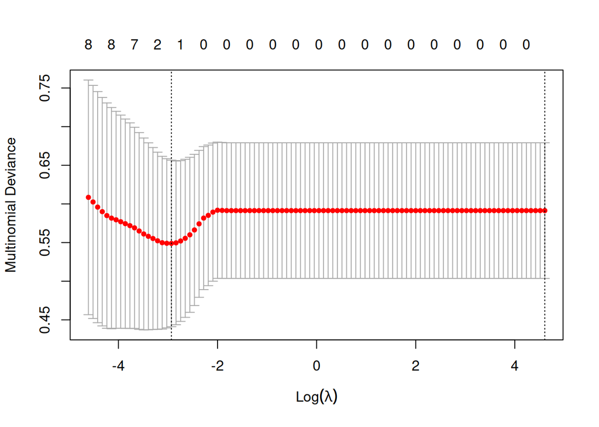

```r
lambdas_to_try <- 10^seq(-2, 2, length.out = 100)
lasso_cv <- cv.glmnet(ecological_factor_processed, pop_size, alpha = 1,  lambda = lambdas_to_try,
                      standardize = TRUE, nfolds = 5, family = "multinomial")
plot(lasso_cv) # Plot cross-validation results
```

Fit final model, get its sum of squared residuals and multiple R-squared

```r
lambda_cv <- lasso_cv$lambda.min
model_cv <- glmnet(ecological_factor_processed, pop_size, alpha = 1, lambda = lambda_cv, standardize = TRUE, family = "mgaussian")
```

See how increasing lambda shrinks the coefficients Each line shows coefficients for one variables, for different lambdas. The higher the lambda, the more the coefficients are shrinked towards zero.

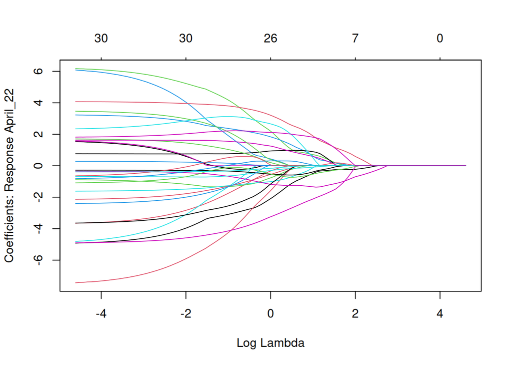

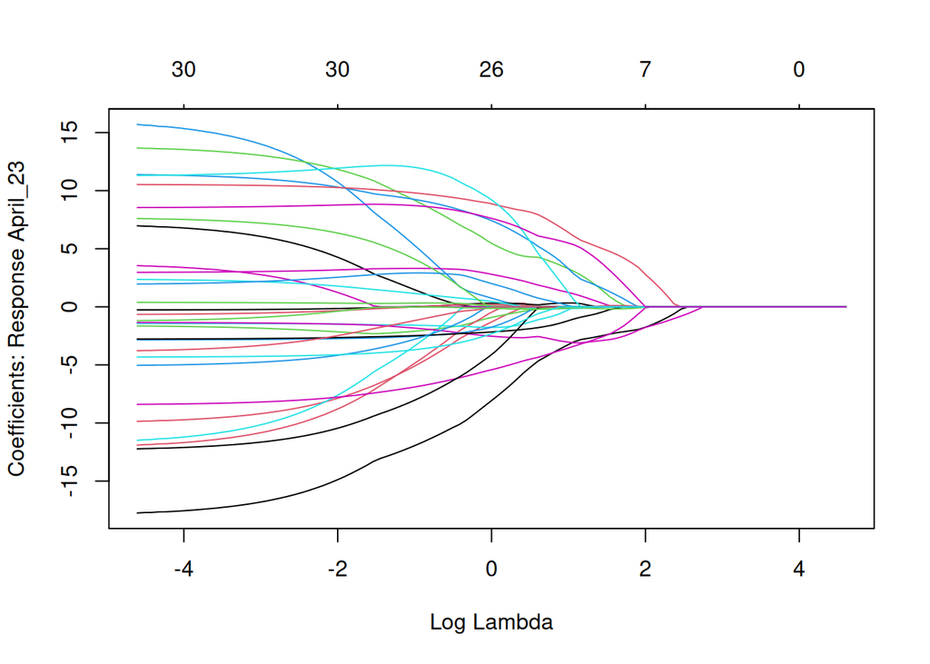

```r
res <- glmnet(ecological_factor_processed, pop_size, alpha = 1, lambda = lambdas_to_try, standardize = TRUE, family = "mgaussian")
plot(res, xvar = "lambda")
```

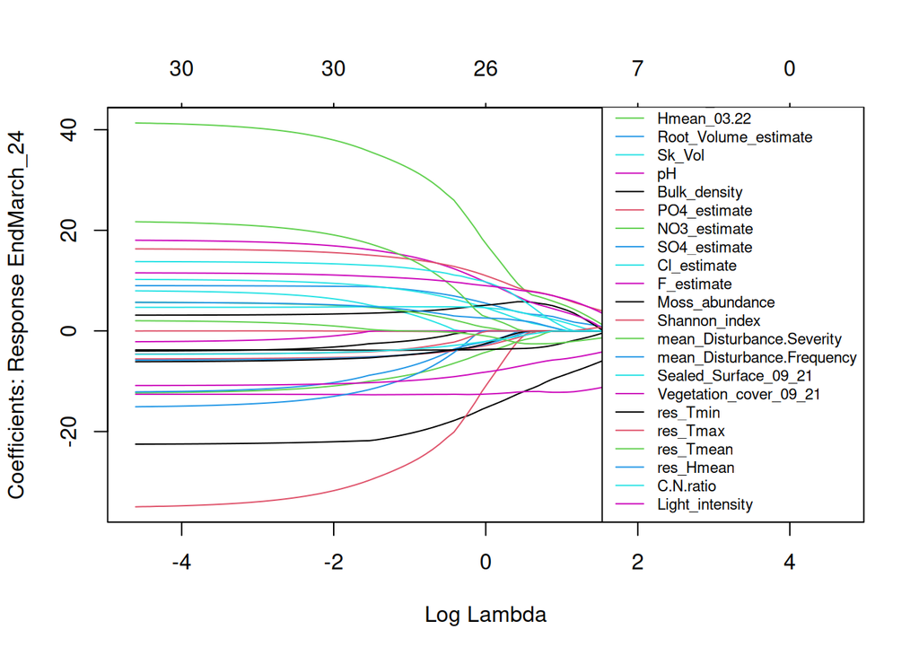

```r
legend("bottomright", lwd = 1, col = 1:6, legend = colnames(ecological_factor_processed), cex = .7)
```

## Coefficient explaining the best the establishment in absoulute value

```r
coef_lasso <- coef(model_cv, s = "lambda.min")
coef_April22 <- coef_lasso[[1]]
coef_April22 <- as.matrix(coef_April22)
coef_April22 <- coef_April22[coef_April22 != 0, , drop = FALSE]
coef_April22 <- coef_April22[rownames(coef_April22) != "(Intercept)", , drop = FALSE]
coef_April22 <- coef_April22[order(abs(coef_April22[,1]), decreasing = TRUE), , drop = FALSE]
coef_April22 <- as.data.frame(coef_April22[1:10,])
coef_April22$Variable <- rownames(coef_April22)
colnames(coef_April22)[1] <- "Coefficient_April22"
```

```r
coef_April23 <-coef_lasso[[2]]
coef_April23 <- as.matrix(coef_April23)
coef_April23 <- coef_April23[coef_April23 != 0, , drop = FALSE]
coef_April23 <- coef_April23[rownames(coef_April23) != "(Intercept)", , drop = FALSE]
coef_April23 <- coef_April23[order(abs(coef_April23[,1]), decreasing = TRUE), , drop = FALSE]
coef_April23 <- as.data.frame(coef_April23[1:10,])
coef_April23$Variable <- rownames(coef_April23)
colnames(coef_April23)[1] <- "Coefficient_April23"
```

```r
coef_April24 <-coef_lasso[[3]]
coef_April24 <- as.matrix(coef_April24)
coef_April24 <- coef_April24[coef_April24 != 0, , drop = FALSE]
coef_April24 <- coef_April24[rownames(coef_April24) != "(Intercept)", , drop = FALSE]
coef_April24 <- coef_April24[order(abs(coef_April24[,1]), decreasing = TRUE), , drop = FALSE]
coef_April24 <- as.data.frame(coef_April24[1:10,])
coef_April24$Variable <- rownames(coef_April24)
colnames(coef_April24)[1] <- "Coefficient_April23"
```

```r
coef_pop_size <- merge(x = coef_April22, y = coef_April23, by = "Variable",
                       all = TRUE)
coef_pop_size <- merge(x = coef_pop_size, y = coef_April24, by = "Variable",
                       all = TRUE)
colnames(coef_pop_size) <- c("Variable", "April22", "April23", "April24")
coef_pop_size <- reshape2::melt(coef_pop_size, id.vars = "Variable", variable.name = "Time",
                                   value.name="Coefficient")
coef_pop_size <- coef_pop_size %>% drop_na(Coefficient)
coef_pop_size$Coefficient <- as.numeric(coef_pop_size$Coefficient)
coef_pop_size_methods <- data.frame("Lasso"= unique(coef_pop_size$Variable))
```

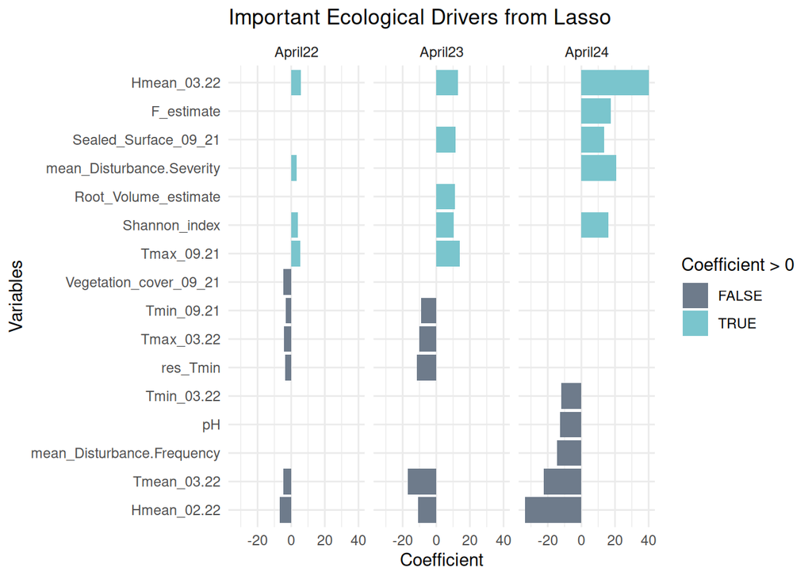

```r
ggplot(coef_pop_size, aes(x =reorder(Variable, Coefficient), y = Coefficient, fill = Coefficient > 0, group = Time)) +
  geom_bar(stat = "identity") +
  coord_flip() +
  scale_fill_manual(values = c("#6E7B8B", "#7AC5CD")) +
  labs(title = "Important Ecological Drivers from Lasso",
       x = "Variables", y = "Coefficient") +
  theme_minimal() +
  facet_wrap(vars(Time))
```

```r
#ggsave("Population_size_April.svg", plot = last_plot(),dpi = 900, bg = NULL, scale = 2 )
```

# III. LASSO: Population size April ~ ecological factor per type of habitat

## 1. Meadow

```r
ecological_factor <- data_pop %>% filter(Type=="grass") %>% dplyr::select(6:35)
preprocessParams<-preProcess(ecological_factor, method = c("center", "scale"))
ecological_factor_processed <- predict(preprocessParams, ecological_factor)
ecological_factor_processed <- as.matrix(ecological_factor_processed)  # Convert to matrix
```

```r
pop_size <- data_pop %>% filter(Type=="grass") %>% dplyr::select(3:5)
pop_size <- as.matrix(pop_size)  # classification
```

```r
lambdas_to_try <- 10^seq(-2, 2, length.out = 100)
lasso_cv <- cv.glmnet(ecological_factor_processed, pop_size, alpha = 1,  lambda = lambdas_to_try,
                      standardize = TRUE, nfolds = 5, family = "mgaussian")
# Fit final model, get its sum of squared residuals and multiple R-squared
lambda_cv <- lasso_cv$lambda.min
model_cv <- glmnet(ecological_factor_processed, pop_size, alpha = 1, lambda = lambda_cv, standardize = TRUE, family = "mgaussian")
res <- glmnet(ecological_factor_processed, pop_size, alpha = 1, lambda = lambdas_to_try, standardize = TRUE, family = "mgaussian")
```

### Coefficient explaining the best the establishment in absoulute value

```r
coef_lasso <- coef(model_cv, s = "lambda.min")
```

No variable is selected by the Lasso model, may be due to the small number of population ?

## 2. Pavement

```r
ecological_factor <- data_pop %>% filter(Type=="pavement") %>% dplyr::select(6:35)
preprocessParams<-preProcess(ecological_factor, method = c("center", "scale"))
ecological_factor_processed <- predict(preprocessParams, ecological_factor)
ecological_factor_processed <- as.matrix(ecological_factor_processed)  # Convert to matrix
```

```r
pop_size <- data_pop %>% filter(Type=="pavement") %>% dplyr::select(3:5)
pop_size <- as.matrix(pop_size)  # classification
```

```r
lambdas_to_try <- 10^seq(-2, 2, length.out = 100)
lasso_cv <- cv.glmnet(ecological_factor_processed, pop_size, alpha = 1,  lambda = lambdas_to_try,
                      standardize = TRUE, nfolds = 5, family = "mgaussian")
# Fit final model, get its sum of squared residuals and multiple R-squared
lambda_cv <- lasso_cv$lambda.min
model_cv <- glmnet(ecological_factor_processed, pop_size, alpha = 1, lambda = lambda_cv, standardize = TRUE, family = "mgaussian")
res <- glmnet(ecological_factor_processed, pop_size, alpha = 1, lambda = lambdas_to_try, standardize = TRUE, family = "mgaussian")
```

### Coefficient explaining the best the establishment in absoulute value

```r
coef_lasso <- coef(model_cv, s = "lambda.min")
coef_April22 <- coef_lasso[[1]]
coef_April22 <- as.matrix(coef_April22)
coef_April22 <- coef_April22[coef_April22 != 0, , drop = FALSE]
coef_April22 <- coef_April22[rownames(coef_April22) != "(Intercept)", , drop = FALSE]
coef_April22 <- coef_April22[order(abs(coef_April22[,1]), decreasing = TRUE), , drop = FALSE]
coef_April22 <- as.data.frame(coef_April22)
coef_April22$Variable <- rownames(coef_April22)
colnames(coef_April22)[1] <- "Coefficient_April22"
```

```r
coef_April23 <-coef_lasso[[2]]
coef_April23 <- as.matrix(coef_April23)
coef_April23 <- coef_April23[coef_April23 != 0, , drop = FALSE]
coef_April23 <- coef_April23[rownames(coef_April23) != "(Intercept)", , drop = FALSE]
coef_April23 <- coef_April23[order(abs(coef_April23[,1]), decreasing = TRUE), , drop = FALSE]
coef_April23 <- as.data.frame(coef_April23)
coef_April23$Variable <- rownames(coef_April23)
colnames(coef_April23)[1] <- "Coefficient_April23"
```

```r
coef_April24 <-coef_lasso[[3]]
coef_April24 <- as.matrix(coef_April24)
coef_April24 <- coef_April24[coef_April24 != 0, , drop = FALSE]
coef_April24 <- coef_April24[rownames(coef_April24) != "(Intercept)", , drop = FALSE]
coef_April24 <- coef_April24[order(abs(coef_April24[,1]), decreasing = TRUE), , drop = FALSE]
coef_April24 <- as.data.frame(coef_April24)
coef_April24$Variable <- rownames(coef_April24)
colnames(coef_April24)[1] <- "Coefficient_April23"
```

```r
coef_pop_size <- merge(x = coef_April22, y = coef_April23, by = "Variable",
                       all = TRUE)
coef_pop_size <- merge(x = coef_pop_size, y = coef_April24, by = "Variable",
                       all = TRUE)
colnames(coef_pop_size) <- c("Variable", "April22", "April23", "April24")
coef_pop_size <- reshape2::melt(coef_pop_size, id.vars = "Variable", variable.name = "Time",
                                value.name="Coefficient")
coef_pop_size <- coef_pop_size %>% drop_na(Coefficient)
coef_pop_size$Coefficient <- as.numeric(coef_pop_size$Coefficient)
```

```r
# ggplot(coef_pop_size, aes(x =reorder(Variable, Coefficient), y = Coefficient, fill = Coefficient > 0, group = Time)) +
#   geom_bar(stat = "identity") +
#   coord_flip() +
#   scale_fill_manual(values = c("#6E7B8B", "#22a884")) +
#   labs(title = "Important Ecological Drivers from Lasso",
#        x = "Variables", y = "Coefficient") +
#   theme_minimal() +
#   facet_wrap(vars(Time))
```

## 3. Tree bed

```r
ecological_factor <- data_pop %>% filter(Type=="Tree bed") %>% dplyr::select(6:35)
preprocessParams<-preProcess(ecological_factor, method = c("center", "scale"))
ecological_factor_processed <- predict(preprocessParams, ecological_factor)
ecological_factor_processed <- as.matrix(ecological_factor_processed)  # Convert to matrix
```

```r
pop_size <- data_pop %>% filter(Type=="Tree bed") %>% dplyr::select(3:5)
pop_size <- as.matrix(pop_size)  # classification
```

```r
lambdas_to_try <- 10^seq(-2, 2, length.out = 100)
lasso_cv <- cv.glmnet(ecological_factor_processed, pop_size, alpha = 1,  lambda = lambdas_to_try,
                      standardize = TRUE, nfolds = 5, family = "mgaussian")
# Fit final model, get its sum of squared residuals and multiple R-squared
lambda_cv <- lasso_cv$lambda.min
model_cv <- glmnet(ecological_factor_processed, pop_size, alpha = 1, lambda = lambda_cv, standardize = TRUE, family = "mgaussian")
res <- glmnet(ecological_factor_processed, pop_size, alpha = 1, lambda = lambdas_to_try, standardize = TRUE, family = "mgaussian")
```

### Coefficient explaining the best the establishment in absoulute value

```r
coef_lasso <- coef(model_cv, s = "lambda.min")
```

No variable is selected by the Lasso model, may be due to the small number of population ?

## 4. Wall

I only kept the non estimated variable for the wall, so no temperature and soil variables.  
I am adding the Ellenberg value instead

```r
# Uni directory:  - Floret, Justine (jfloret@uni-koeln.de)@uni-koeln.sciebo.de
ellenberg_data <- read_csv("/home/justine/sciebo/2_Ecological_parameters/2_assays/Ecological_parameters_imputed.csv")
ellenberg_data$Site_ID <- as.factor(ellenberg_data$Site_ID)
ellenberg_data$Type <- as.factor(ellenberg_data$Type)
ellenberg_data$Destroyed <- as.factor(ellenberg_data$Destroyed)
ellenberg_data$Outliers_soil <- as.factor(ellenberg_data$Outliers_soil)
ellenberg_data$Sowing_1st <- as.factor(ellenberg_data$Sowing_1st)
ellenberg_data$Sowing_2nd <- as.factor(ellenberg_data$Sowing_2nd)
ellenberg_data$Germ_2ndyear <- as.factor(ellenberg_data$Germ_2ndyear)
ellenberg_data <- ellenberg_data %>% dplyr::filter(Destroyed!="02/2022" & Destroyed !="05/2022") #Removing the destroyed site before 03/2022
ellenberg_data <- ellenberg_data %>% dplyr::filter(Sowing_1st == "09/2021" & Sowing_2nd == "no" ) #Keep the first sowing

ellenberg_data <- merge(data_pop, ellenberg_data[,c(1,120:125)], by= "Site_ID")
```

```r
ecological_factor <- ellenberg_data %>% filter(Type=="wall") %>% dplyr::select(15,24:29,35:41)
preprocessParams<-preProcess(ecological_factor, method = c("center", "scale"))
ecological_factor_processed <- predict(preprocessParams, ecological_factor)
ecological_factor_processed <- as.matrix(ecological_factor_processed)  # Convert to matrix
```

```r
pop_size <- ellenberg_data %>% filter(Type=="wall") %>% dplyr::select(3:5)
pop_size <- as.matrix(pop_size)  # classification
```

```r
lambdas_to_try <- 10^seq(-2, 2, length.out = 100)
lasso_cv <- cv.glmnet(ecological_factor_processed, pop_size, alpha = 1,  lambda = lambdas_to_try,
                      standardize = TRUE, nfolds = 5, family = "mgaussian")
# Fit final model, get its sum of squared residuals and multiple R-squared
lambda_cv <- lasso_cv$lambda.min
model_cv <- glmnet(ecological_factor_processed, pop_size, alpha = 1, lambda = lambda_cv, standardize = TRUE, family = "mgaussian")
res <- glmnet(ecological_factor_processed, pop_size, alpha = 1, lambda = lambdas_to_try, standardize = TRUE, family = "mgaussian")
```

### Coefficient explaining the best the establishment in absoulute value

```r
coef_lasso <- coef(model_cv, s = "lambda.min")
```

No variable is selected by the Lasso model, may be due to the small number of population ?

# IV. LASSO: Population size April2022 ~ ecological factor

The different ecological parameters have been measured in April 2022 only.  
Since I can not take into account the yearly variation of the micro environmental variable I will look at the population size in Apeil 2022 only.  
Preparing the ecological factor variable

```r
data_pop_April22 <- data_pop %>% filter(April_22 !=0)
ecological_factor <- data_pop_April22[,c(6:35)]
preprocessParams<-preProcess(ecological_factor, method = c("center", "scale"))
ecological_factor_processed <- predict(preprocessParams, ecological_factor)
ecological_factor_processed <- as.matrix(ecological_factor_processed)  # Convert to matrix
```

```r
pop_size <- as.matrix(data_pop_April22[,c(3)])
```

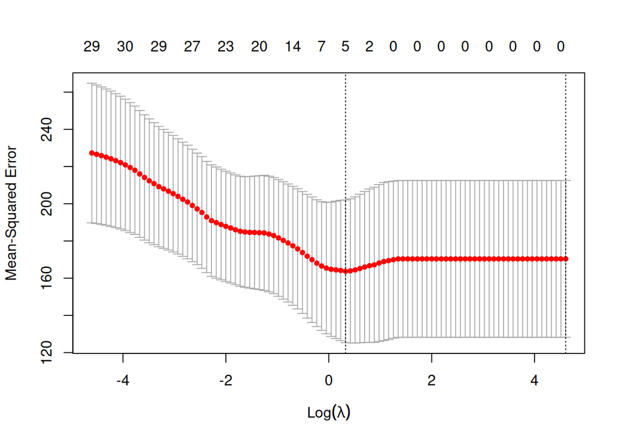

```r
lambdas_to_try <- 10^seq(-2, 2, length.out = 100)
lasso_cv <- cv.glmnet(ecological_factor_processed, pop_size, alpha = 1,  lambda = lambdas_to_try,
                      standardize = TRUE, nfolds = 5, family = "gaussian")
plot(lasso_cv) # Plot cross-validation results
```

Fit final model, get its sum of squared residuals and multiple R-squared

```r
lambda_cv <- lasso_cv$lambda.min
model_cv <- glmnet(ecological_factor_processed, pop_size, alpha = 1, lambda = lambda_cv, standardize = TRUE, family = "gaussian")
```

See how increasing lambda shrinks the coefficients Each line shows coefficients for one variables, for different lambdas. The higher the lambda, the more the coefficients are shrinked towards zero.

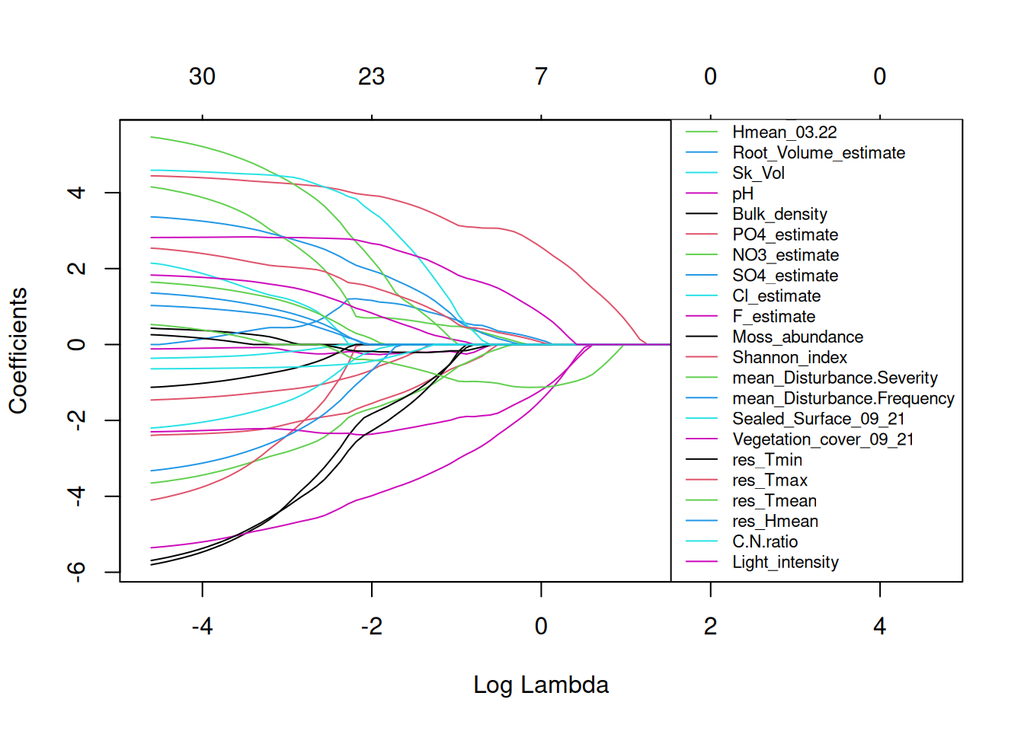

```r
res <- glmnet(ecological_factor_processed, pop_size, alpha = 1, lambda = lambdas_to_try, standardize = TRUE, family = "gaussian")
plot(res, xvar = "lambda")
legend("bottomright", lwd = 1, col = 1:6, legend = colnames(ecological_factor_processed), cex = .7)
```

## Coefficient explaining the best the establishment in absoulute value

```r
coef_April22 <- coef(model_cv, s = "lambda.min")
coef_April22 <- as.matrix(coef_April22)
coef_April22 <- coef_April22[coef_April22 != 0, , drop = FALSE]
coef_April22 <- coef_April22[rownames(coef_April22) != "(Intercept)", , drop = FALSE]
coef_April22 <- coef_April22[order(abs(coef_April22[,1]), decreasing = TRUE), , drop = FALSE]
coef_April22 <- as.data.frame(coef_April22)
coef_April22$Variable <- rownames(coef_April22)
colnames(coef_April22)[1] <- "Coefficient_April22"
```

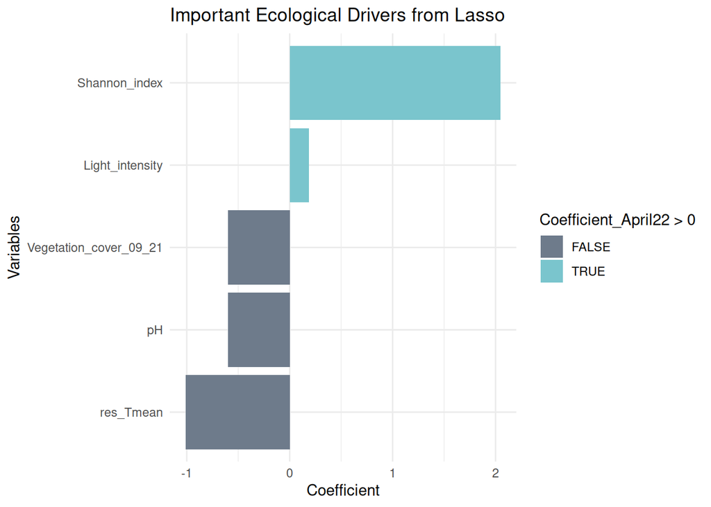

```r
ggplot(coef_April22, aes(x =reorder(Variable, Coefficient_April22), y = Coefficient_April22, fill = Coefficient_April22 > 0)) +
  geom_bar(stat = "identity") +
  coord_flip() +
  scale_fill_manual(values = c("#6E7B8B", "#7AC5CD")) +
  labs(title = "Important Ecological Drivers from Lasso",
       x = "Variables", y = "Coefficient") +
  theme_minimal()
```

```r
#ggsave("Population_size_April22_only.svg", plot = last_plot(),dpi = 900, bg = NULL, scale = 2 )
```

# V. LASSO: Population size April2022 ~ ecological factor per type of habitat

## 1. Meadow

```r
ecological_factor <- data_pop_April22 %>% filter(Type=="grass") %>% dplyr::select(6:35)
preprocessParams<-preProcess(ecological_factor, method = c("center", "scale"))
ecological_factor_processed <- predict(preprocessParams, ecological_factor)
ecological_factor_processed <- as.matrix(ecological_factor_processed)  # Convert to matrix
```

```r
pop_size <- data_pop_April22 %>% filter(Type=="grass") %>% dplyr::select(3)
pop_size <- as.matrix(pop_size)  # classification
```

```r
lambdas_to_try <- 10^seq(-2, 2, length.out = 100)
lasso_cv <- cv.glmnet(ecological_factor_processed, pop_size, alpha = 1,  lambda = lambdas_to_try,
                      standardize = TRUE, nfolds = 5, family = "gaussian")
# Fit final model, get its sum of squared residuals and multiple R-squared
lambda_cv <- lasso_cv$lambda.min
model_cv <- glmnet(ecological_factor_processed, pop_size, alpha = 1, lambda = lambda_cv, standardize = TRUE, family = "gaussian")
res <- glmnet(ecological_factor_processed, pop_size, alpha = 1, lambda = lambdas_to_try, standardize = TRUE, family = "gaussian")
```

### Coefficient explaining the best the establishment in absoulute value

```r
coef_lasso <- coef(model_cv, s = "lambda.min")
```

No variable is selected by the Lasso model, may be due to the small number of population ?

## 2. Pavement

```r
ecological_factor <- data_pop_April22 %>% filter(Type=="pavement") %>% dplyr::select(6:35)
preprocessParams<-preProcess(ecological_factor, method = c("center", "scale"))
ecological_factor_processed <- predict(preprocessParams, ecological_factor)
ecological_factor_processed <- as.matrix(ecological_factor_processed)  # Convert to matrix
```

```r
pop_size <- data_pop_April22 %>% filter(Type=="pavement") %>% dplyr::select(3)
pop_size <- as.matrix(pop_size)  # classification
```

```r
lambdas_to_try <- 10^seq(-2, 2, length.out = 100)
lasso_cv <- cv.glmnet(ecological_factor_processed, pop_size, alpha = 1,  lambda = lambdas_to_try,
                      standardize = TRUE, nfolds = 5, family = "gaussian")
# Fit final model, get its sum of squared residuals and multiple R-squared
lambda_cv <- lasso_cv$lambda.min
model_cv <- glmnet(ecological_factor_processed, pop_size, alpha = 1, lambda = lambda_cv, standardize = TRUE, family = "gaussian")
res <- glmnet(ecological_factor_processed, pop_size, alpha = 1, lambda = lambdas_to_try, standardize = TRUE, family = "gaussian")
```

### Coefficient explaining the best the establishment in absoulute value

```r
coef_April22 <- coef(model_cv, s = "lambda.min")
coef_April22 <- as.matrix(coef_April22)
coef_April22 <- coef_April22[coef_April22 != 0, , drop = FALSE]
coef_April22 <- coef_April22[rownames(coef_April22) != "(Intercept)", , drop = FALSE]
coef_April22 <- coef_April22[order(abs(coef_April22[,1]), decreasing = TRUE), , drop = FALSE]
coef_April22 <- as.data.frame(coef_April22)
coef_April22$Variable <- rownames(coef_April22)
colnames(coef_April22)[1] <- "Coefficient_April22"
```

[figure not shown]

```r
ggplot(coef_April22, aes(x =reorder(Variable, Coefficient_April22), y = Coefficient_April22, fill = Coefficient_April22 > 0)) +
  geom_bar(stat = "identity") +
  coord_flip() +
  scale_fill_manual(values = c("#6D8C8F","#22a884")) +
  labs(title = "Important Ecological Drivers from Lasso",
       x = "Variables", y = "Coefficient") +
  theme_minimal()
```

## 3. Tree bed

```r
ecological_factor <- data_pop_April22 %>% filter(Type=="Tree bed") %>% dplyr::select(6:35)
preprocessParams<-preProcess(ecological_factor, method = c("center", "scale"))
ecological_factor_processed <- predict(preprocessParams, ecological_factor)
ecological_factor_processed <- as.matrix(ecological_factor_processed)  # Convert to matrix
```

```r
pop_size <- data_pop_April22 %>% filter(Type=="Tree bed") %>% dplyr::select(3)
pop_size <- as.matrix(pop_size)  # classification
```

```r
lambdas_to_try <- 10^seq(-2, 2, length.out = 100)
lasso_cv <- cv.glmnet(ecological_factor_processed, pop_size, alpha = 1,  lambda = lambdas_to_try,
                      standardize = TRUE, nfolds = 5, family = "gaussian")
# Fit final model, get its sum of squared residuals and multiple R-squared
lambda_cv <- lasso_cv$lambda.min
model_cv <- glmnet(ecological_factor_processed, pop_size, alpha = 1, lambda = lambda_cv, standardize = TRUE, family = "gaussian")
res <- glmnet(ecological_factor_processed, pop_size, alpha = 1, lambda = lambdas_to_try, standardize = TRUE, family = "gaussian")
```

### Coefficient explaining the best the establishment in absoulute value

```r
coef_April22 <- coef(model_cv, s = "lambda.min")
coef_April22 <- as.matrix(coef_April22)
coef_April22 <- coef_April22[coef_April22 != 0, , drop = FALSE]
coef_April22 <- coef_April22[rownames(coef_April22) != "(Intercept)", , drop = FALSE]
coef_April22 <- coef_April22[order(abs(coef_April22[,1]), decreasing = TRUE), , drop = FALSE]
coef_April22 <- as.data.frame(coef_April22)
coef_April22$Variable <- rownames(coef_April22)
colnames(coef_April22)[1] <- "Coefficient_April22"
```

[figure not shown]

```r
ggplot(coef_April22, aes(x =reorder(Variable, Coefficient_April22), y = Coefficient_April22, fill = Coefficient_April22 > 0)) +
  geom_bar(stat = "identity") +
  coord_flip() +
  scale_fill_manual(values = c("#6E7B8B", "#355f8d")) +
  labs(title = "Important Ecological Drivers from Lasso",
       x = "Variables", y = "Coefficient") +
  theme_minimal()
```

## 4. Wall

I only kept the non estimated variable for the wall, so no temperature and soil variables.  
I am adding the Ellenberg value instead

```r
# Uni directory:  - Floret, Justine (jfloret@uni-koeln.de)@uni-koeln.sciebo.de
ellenberg_data <- read_csv("/home/justine/sciebo/2_Ecological_parameters/2_assays/Ecological_parameters_imputed.csv")
ellenberg_data$Site_ID <- as.factor(ellenberg_data$Site_ID)
ellenberg_data$Type <- as.factor(ellenberg_data$Type)
ellenberg_data$Destroyed <- as.factor(ellenberg_data$Destroyed)
ellenberg_data$Outliers_soil <- as.factor(ellenberg_data$Outliers_soil)
ellenberg_data$Sowing_1st <- as.factor(ellenberg_data$Sowing_1st)
ellenberg_data$Sowing_2nd <- as.factor(ellenberg_data$Sowing_2nd)
ellenberg_data$Germ_2ndyear <- as.factor(ellenberg_data$Germ_2ndyear)
ellenberg_data <- ellenberg_data %>% dplyr::filter(Destroyed!="02/2022" & Destroyed !="05/2022") #Removing the destroyed site before 03/2022
ellenberg_data <- ellenberg_data %>% dplyr::filter(Sowing_1st == "09/2021" & Sowing_2nd == "no" ) #Keep the first sowing
ellenberg_data <- merge(data_pop, ellenberg_data[,c(1,120:125)], by= "Site_ID")
ellenberg_data_April22 <- ellenberg_data %>% filter(April_22 !=0)
```

```r
ecological_factor <- ellenberg_data_April22 %>% filter(Type=="wall") %>% dplyr::select(15,24:29,35:41)
preprocessParams<-preProcess(ecological_factor, method = c("center", "scale"))
ecological_factor_processed <- predict(preprocessParams, ecological_factor)
ecological_factor_processed <- as.matrix(ecological_factor_processed)  # Convert to matrix
```

```r
pop_size <- ellenberg_data_April22 %>% filter(Type=="wall") %>% dplyr::select(3)
pop_size <- as.matrix(pop_size)  # classification
```

```r
lambdas_to_try <- 10^seq(-2, 2, length.out = 100)
lasso_cv <- cv.glmnet(ecological_factor_processed, pop_size, alpha = 1,  lambda = lambdas_to_try,
                      standardize = TRUE, nfolds = 5, family = "gaussian")
# Fit final model, get its sum of squared residuals and multiple R-squared
lambda_cv <- lasso_cv$lambda.min
model_cv <- glmnet(ecological_factor_processed, pop_size, alpha = 1, lambda = lambda_cv, standardize = TRUE, family = "gaussian")
res <- glmnet(ecological_factor_processed, pop_size, alpha = 1, lambda = lambdas_to_try, standardize = TRUE, family = "gaussian")
```

### Coefficient explaining the best the establishment in absoulute value

```r
coef_April22 <- coef(model_cv, s = "lambda.min")
coef_April22 <- as.matrix(coef_April22)
coef_April22 <- coef_April22[coef_April22 != 0, , drop = FALSE]
coef_April22 <- coef_April22[rownames(coef_April22) != "(Intercept)", , drop = FALSE]
coef_April22 <- coef_April22[order(abs(coef_April22[,1]), decreasing = TRUE), , drop = FALSE]
coef_April22 <- as.data.frame(coef_April22)
coef_April22$Variable <- rownames(coef_April22)
colnames(coef_April22)[1] <- "Coefficient_April22"
```

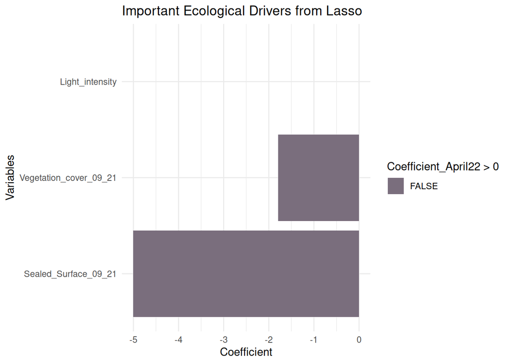

```r
ggplot(coef_April22, aes(x =reorder(Variable, Coefficient_April22), y = Coefficient_April22, fill = Coefficient_April22 > 0)) +
  geom_bar(stat = "identity") +
  coord_flip() +
  scale_fill_manual(values = c("#7A6E7D", "#440154")) +
  labs(title = "Important Ecological Drivers from Lasso",
       x = "Variables", y = "Coefficient") +
  theme_minimal()
```

# VI. RDA: Population size April ~ ecological factor

Preparing the ecological factor variable

```r
ecological_factor <- decostand(data_pop[,c(6:35)], method = "standardize") # Scale and center variables
data_pop_standardize <- cbind(data_pop[,c(3:5)], ecological_factor)
```

RDA model 1

```r
RDA_mod1 <- rda(data_pop_standardize[,1:3] ~ ., data = data_pop_standardize[,c(4:33)])
summary(RDA_mod1)
```

```
##
## Call:
## rda(formula = data_pop_standardize[, 1:3] ~ DD_04.22 + Tmin_09.21 +      Tmin_03.22 + Tmax_09.21 + Tmax_03.22 + Tmean_09.21 + Tmean_03.22 +      Hmean_02.22 + Hmean_03.22 + Root_Volume_estimate + Sk_Vol +      pH + Bulk_density + PO4_estimate + NO3_estimate + SO4_estimate +      Cl_estimate + F_e…
##
## Partitioning of variance:
##               Inertia Proportion
## Total            5617     1.0000
## Constrained      1423     0.2534
## Unconstrained    4194     0.7466
##
## Eigenvalues, and their contribution to the variance
##
## Importance of components:
##                            RDA1      RDA2     RDA3       PC1      PC2      PC3
## Eigenvalue            1262.1355 151.73002 9.518546 3428.8693 692.3620 72.85697
## Proportion Explained     0.2247   0.02701 0.001694    0.6104   0.1233  0.01297
## Cumulative Proportion    0.2247   0.25169 0.253385    0.8638   0.9870  1.00000
##
## Accumulated constrained eigenvalues
## Importance of components:
##                            RDA1     RDA2     RDA3
## Eigenvalue            1262.1355 151.7300 9.518546
## Proportion Explained     0.8867   0.1066 0.006687
## Cumulative Proportion    0.8867   0.9933 1.000000
```

```r
fwd.sel <- ordiR2step(rda(data_pop_standardize[,1:3] ~ 1, data = data_pop_standardize[,c(4:33)]), # lower model limit (simple!)
                        scope = formula(RDA_mod1), # upper model limit (the "full" model)
                        direction = "forward",
                        R2scope = TRUE, # can't surpass the "full" model's R2
                        pstep = 1000,
                        trace = FALSE) # change to TRUE to see the selection process!
fwd.sel$call
```

```
## rda(formula = data_pop_standardize[, 1:3] ~ pH + Tmean_03.22 +
##     Shannon_index + Vegetation_cover_09_21, data = data_pop_standardize[,
##     c(4:33)])
```

Rsquared of the model Testing the new model:

```r
RDA_mod2 <- rda(formula = data_pop_standardize[, 1:3] ~ pH + Tmean_03.22 +
                  Shannon_index + Vegetation_cover_09_21, data = data_pop_standardize[,c(4:33)])
summary(RDA_mod2)
```

```
##
## Call:
## rda(formula = data_pop_standardize[, 1:3] ~ pH + Tmean_03.22 +      Shannon_index + Vegetation_cover_09_21, data = data_pop_standardize[,      c(4:33)])
##
## Partitioning of variance:
##               Inertia Proportion
## Total          5617.5     1.0000
## Constrained     616.5     0.1097
## Unconstrained  5001.0     0.8903
##
## Eigenvalues, and their contribution to the variance
##
## Importance of components:
##                           RDA1      RDA2      RDA3       PC1      PC2      PC3
## Eigenvalue            575.8899 37.649137 2.9713444 4110.5607 808.1041 82.29715
## Proportion Explained    0.1025  0.006702 0.0005289    0.7317   0.1439  0.01465
## Cumulative Proportion   0.1025  0.109220 0.1097487    0.8415   0.9853  1.00000
##
## Accumulated constrained eigenvalues
## Importance of components:
##                           RDA1     RDA2    RDA3
## Eigenvalue            575.8899 37.64914 2.97134
## Proportion Explained    0.9341  0.06107 0.00482
## Cumulative Proportion   0.9341  0.99518 1.00000
```

```r
RsquareAdj(RDA_mod2)
```

```
## $r.squared
## [1] 0.1097487
##
## $adj.r.squared
## [1] 0.08916487
```

```r
anova.cca(RDA_mod2, step = 1000)
```

|  | Df | Variance | F | Pr(>F) |
| --- | --- | --- | --- | --- |
| Model | 4 | 616.5104 | 5.331789 | 0.001 |
| Residual | 173 | 5000.9620 | NA | NA |

```r
anova.cca(RDA_mod2, step = 1000, by = "terms")
```

|  | Df | Variance | F | Pr(>F) |
| --- | --- | --- | --- | --- |
| pH | 1 | 247.5690 | 8.564238 | 0.006 |
| Tmean_03.22 | 1 | 144.5730 | 5.001264 | 0.015 |
| Shannon_index | 1 | 115.5645 | 3.997762 | 0.033 |
| Vegetation_cover_09_21 | 1 | 108.8039 | 3.763892 | 0.032 |
| Residual | 173 | 5000.9620 | NA | NA |

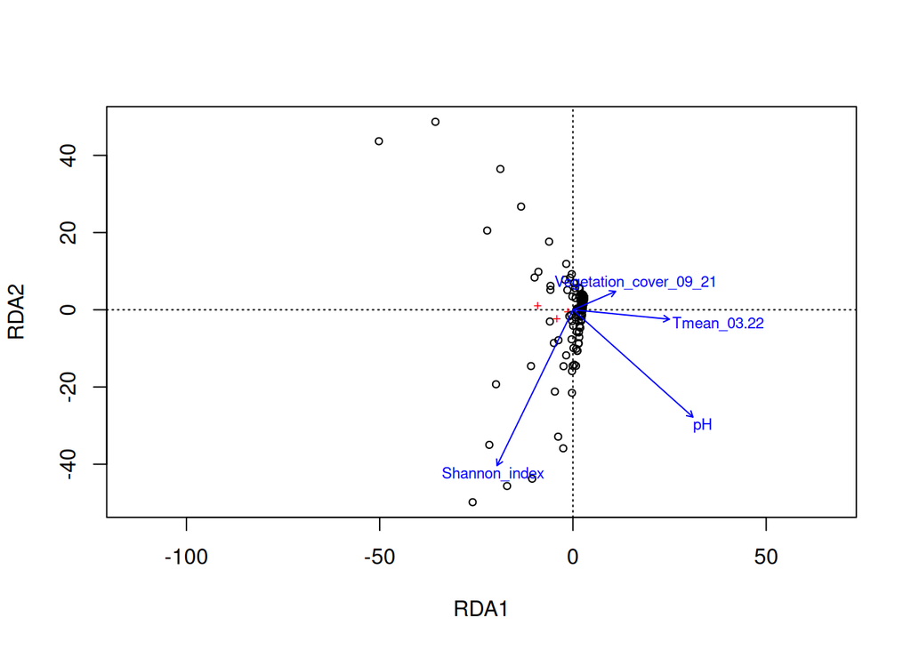

```r
ordiplot(RDA_mod2, type = "points")
```

# VIII. GLM: Aprils ~ ecological factor /Time

```r
data_size_glm <- data_pop[,(names(data_pop) %in% coef_pop_size_methods$Lasso)]
data_size_glm$Light_intensity <- data_pop$Light_intensity
data_size_glm$Type <- as.factor(data_pop$Type)
data_size_glm$April_22 <- as.factor(data_pop$April_22)
data_size_glm$EndMarch_24 <- as.factor(data_pop$EndMarch_24)
data_size_glm$April_23 <- as.factor(data_pop$April_23)
data_size_glm <- pivot_longer(data_size_glm, cols = c("April_22","April_23", "EndMarch_24"),
                              names_to = "TimePoint", values_to = "PopulationSize")
data_size_glm$PopulationSize <- as.numeric(data_size_glm$PopulationSize)
```

```r
null_model <- glmmTMB(PopulationSize ~ 1 + (1 | TimePoint),data = data_size_glm)
summary(null_model)
```

```
##  Family: gaussian  ( identity )
## Formula:          PopulationSize ~ 1 + (1 | TimePoint)
## Data: data_size_glm
##
##       AIC       BIC    logLik -2*log(L)  df.resid
##    4585.3    4598.1   -2289.6    4579.3       531
##
## Random effects:
##
## Conditional model:
##  Groups    Name        Variance Std.Dev.
##  TimePoint (Intercept)   6.889   2.625
##  Residual              307.514  17.536
## Number of obs: 534, groups:  TimePoint, 3
##
## Dispersion estimate for gaussian family (sigma^2):  308
##
## Conditional model:
##             Estimate Std. Error z value Pr(>|z|)
## (Intercept)   12.081      1.695   7.128 1.02e-12 ***
## ---
## Signif. codes:  0 '***' 0.001 '**' 0.01 '*' 0.05 '.' 0.1 ' ' 1
```

```r
modAprils <- glmmTMB(PopulationSize ~ (Tmin_09.21 + Tmax_03.22 +Tmean_03.22 + Hmean_03.22 +
                            Root_Volume_estimate +pH +Shannon_index+Sealed_Surface_09_21+
                            Vegetation_cover_09_21+ res_Tmin  +Light_intensity +
                            mean_Disturbance.Severity + mean_Disturbance.Frequency) +(1|TimePoint),
        family = nbinom2,
        data = data_size_glm)
summary(modAprils)
```

```
##  Family: nbinom2  ( log )
## Formula:
## PopulationSize ~ (Tmin_09.21 + Tmax_03.22 + Tmean_03.22 + Hmean_03.22 +
##     Root_Volume_estimate + pH + Shannon_index + Sealed_Surface_09_21 +
##     Vegetation_cover_09_21 + res_Tmin + Light_intensity + mean_Disturbance.Severity +
##     mean_Disturbance.Frequency) + (1 | TimePoint)
## Data: data_size_glm
##
##       AIC       BIC    logLik -2*log(L)  df.resid
##    3606.5    3674.9   -1787.2    3574.5       518
##
## Random effects:
##
## Conditional model:
##  Groups    Name        Variance Std.Dev.
##  TimePoint (Intercept) 0.04819  0.2195
## Number of obs: 534, groups:  TimePoint, 3
##
## Dispersion parameter for nbinom2 family (): 0.825
##
## Conditional model:
##                              Estimate Std. Error z value Pr(>|z|)
## (Intercept)                 6.7726261  1.4973076   4.523 6.09e-06 ***
## Tmin_09.21                  0.0606301  0.0605388   1.002 0.316581
## Tmax_03.22                 -0.0449421  0.0318015  -1.413 0.157595
## Tmean_03.22                -0.1887587  0.0531079  -3.554 0.000379 ***
## Hmean_03.22                 0.0083076  0.0030932   2.686 0.007236 **
## Root_Volume_estimate        1.2849670  0.4293878   2.993 0.002767 **
## pH                         -0.6217115  0.1521205  -4.087 4.37e-05 ***
## Shannon_index               0.6398849  0.1523265   4.201 2.66e-05 ***
## Sealed_Surface_09_21        1.6886314  0.3235566   5.219 1.80e-07 ***
## Vegetation_cover_09_21     -0.8280293  0.2181484  -3.796 0.000147 ***
## res_Tmin                   -0.7667165  0.2531976  -3.028 0.002461 **
## Light_intensity             0.0004099  0.0001283   3.195 0.001397 **
## mean_Disturbance.Severity   0.4191999  1.0967308   0.382 0.702293
## mean_Disturbance.Frequency -0.6791209  0.4478414  -1.516 0.129410
## ---
## Signif. codes:  0 '***' 0.001 '**' 0.01 '*' 0.05 '.' 0.1 ' ' 1
```

```r
car::Anova(modAprils)
```

|  | Chisq | Df | Pr(>Chisq) |
| --- | --- | --- | --- |
| Tmin_09.21 | 1.0030196 | 1 | 3.165810e-01 |
| Tmax_03.22 | 1.9971485 | 1 | 1.575954e-01 |
| Tmean_03.22 | 12.6326838 | 1 | 3.790606e-04 |
| Hmean_03.22 | 7.2135463 | 1 | 7.235539e-03 |
| Root_Volume_estimate | 8.9553894 | 1 | 2.766522e-03 |
| pH | 16.7032940 | 1 | 4.370505e-05 |
| Shannon_index | 17.6462625 | 1 | 2.660376e-05 |
| Sealed_Surface_09_21 | 27.2376292 | 1 | 1.799226e-07 |
| Vegetation_cover_09_21 | 14.4074556 | 1 | 1.472183e-04 |
| res_Tmin | 9.1696049 | 1 | 2.460677e-03 |

[output cut: 3 more lines]

```r
modAprils <- glmmTMB(PopulationSize ~  Tmean_03.22 + Hmean_03.22 +
                                         Root_Volume_estimate +pH +Shannon_index+Sealed_Surface_09_21+
                                         Vegetation_cover_09_21+ res_Tmin  +Light_intensity +
                                          (1|TimePoint),
                     family = nbinom2,
                     data = data_size_glm)
summary(modAprils)
```

```
##  Family: nbinom2  ( log )
## Formula:
## PopulationSize ~ Tmean_03.22 + Hmean_03.22 + Root_Volume_estimate +
##     pH + Shannon_index + Sealed_Surface_09_21 + Vegetation_cover_09_21 +
##     res_Tmin + Light_intensity + (1 | TimePoint)
## Data: data_size_glm
##
##       AIC       BIC    logLik -2*log(L)  df.resid
##    3604.4    3655.7   -1790.2    3580.4       522
##
## Random effects:
##
## Conditional model:
##  Groups    Name        Variance Std.Dev.
##  TimePoint (Intercept) 0.05009  0.2238
## Number of obs: 534, groups:  TimePoint, 3
##
## Dispersion parameter for nbinom2 family (): 0.817
##
## Conditional model:
##                          Estimate Std. Error z value Pr(>|z|)
## (Intercept)             6.7010006  1.2559192   5.336 9.53e-08 ***
## Tmean_03.22            -0.2190586  0.0475142  -4.610 4.02e-06 ***
## Hmean_03.22             0.0098942  0.0028693   3.448 0.000564 ***
## Root_Volume_estimate    1.2309596  0.4138399   2.974 0.002935 **
## pH                     -0.5730621  0.1488142  -3.851 0.000118 ***
## Shannon_index           0.7264766  0.1275278   5.697 1.22e-08 ***
## Sealed_Surface_09_21    1.3707332  0.2631266   5.209 1.89e-07 ***
## Vegetation_cover_09_21 -0.8485023  0.1976506  -4.293 1.76e-05 ***
## res_Tmin               -0.7669963  0.2266050  -3.385 0.000712 ***
## Light_intensity         0.0003430  0.0001217   2.819 0.004823 **
## ---
## Signif. codes:  0 '***' 0.001 '**' 0.01 '*' 0.05 '.' 0.1 ' ' 1
```

```r
car::Anova(modAprils)
```

|  | Chisq | Df | Pr(>Chisq) |
| --- | --- | --- | --- |
| Tmean_03.22 | 21.255598 | 1 | 4.019349e-06 |
| Hmean_03.22 | 11.891006 | 1 | 5.640565e-04 |
| Root_Volume_estimate | 8.847546 | 1 | 2.934832e-03 |
| pH | 14.829101 | 1 | 1.177051e-04 |
| Shannon_index | 32.451426 | 1 | 1.222092e-08 |
| Sealed_Surface_09_21 | 27.137918 | 1 | 1.894455e-07 |
| Vegetation_cover_09_21 | 18.429345 | 1 | 1.763216e-05 |
| res_Tmin | 11.456388 | 1 | 7.124867e-04 |
| Light_intensity | 7.944617 | 1 | 4.823064e-03 |

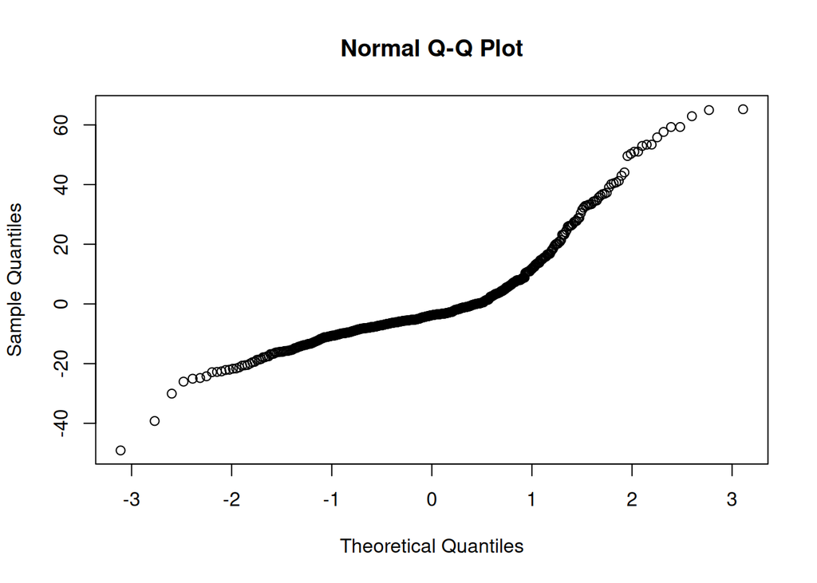

```r
qqnorm(resid(modAprils))
```

```r
mod3Aprils_interactions <- glmmTMB(PopulationSize ~ Tmean_03.22 + Hmean_03.22*TimePoint +
                                     Root_Volume_estimate +pH +Shannon_index+Sealed_Surface_09_21+
                                     Vegetation_cover_09_21+ res_Tmin  +Light_intensity,
                                   family = nbinom2,
                                   data = data_size_glm)
summary(mod3Aprils_interactions)
```

```
##  Family: nbinom2  ( log )
## Formula:
## PopulationSize ~ Tmean_03.22 + Hmean_03.22 * TimePoint + Root_Volume_estimate +
##     pH + Shannon_index + Sealed_Surface_09_21 + Vegetation_cover_09_21 +
##     res_Tmin + Light_intensity
## Data: data_size_glm
##
##       AIC       BIC    logLik -2*log(L)  df.resid
##    3596.3    3660.5   -1783.1    3566.3       519
##
##
## Dispersion parameter for nbinom2 family (): 0.828
##
## Conditional model:
##                                    Estimate Std. Error z value Pr(>|z|)
## (Intercept)                       6.6489331  1.2750166   5.215 1.84e-07 ***
## Tmean_03.22                      -0.2151430  0.0473343  -4.545 5.49e-06 ***
## Hmean_03.22                       0.0045172  0.0045037   1.003 0.315865
## TimePointApril_23                 0.1910157  0.5390305   0.354 0.723062
## TimePointEndMarch_24             -0.7494385  0.5546071  -1.351 0.176601
## Root_Volume_estimate              1.2436114  0.4154276   2.994 0.002757 **
## pH                               -0.5524490  0.1493737  -3.698 0.000217 ***
## Shannon_index                     0.7225817  0.1263209   5.720 1.06e-08 ***
## Sealed_Surface_09_21              1.3743791  0.2618088   5.250 1.52e-07 ***
## Vegetation_cover_09_21           -0.8564835  0.1965407  -4.358 1.31e-05 ***
## res_Tmin                         -0.7489752  0.2284334  -3.279 0.001043 **
## Light_intensity                   0.0003478  0.0001110   3.132 0.001735 **
## Hmean_03.22:TimePointApril_23     0.0043243  0.0061346   0.705 0.480874
## Hmean_03.22:TimePointEndMarch_24  0.0139269  0.0062870   2.215 0.026748 *
## ---
## Signif. codes:  0 '***' 0.001 '**' 0.01 '*' 0.05 '.' 0.1 ' ' 1
```

```r
car::Anova(mod3Aprils_interactions)
```

|  | Chisq | Df | Pr(>Chisq) |
| --- | --- | --- | --- |
| Tmean_03.22 | 20.658666 | 1 | 5.488819e-06 |
| Hmean_03.22 | 12.790138 | 1 | 3.484514e-04 |
| TimePoint | 22.901143 | 2 | 1.064339e-05 |
| Root_Volume_estimate | 8.961459 | 1 | 2.757346e-03 |
| pH | 13.678417 | 1 | 2.169334e-04 |
| Shannon_index | 32.720759 | 1 | 1.063948e-08 |
| Sealed_Surface_09_21 | 27.557806 | 1 | 1.524688e-07 |
| Vegetation_cover_09_21 | 18.990352 | 1 | 1.313811e-05 |
| res_Tmin | 10.750178 | 1 | 1.042693e-03 |
| Light_intensity | 9.811213 | 1 | 1.734511e-03 |

[output cut: 1 more lines]

## Graphique estimate glm model

```r
glm_result <- summary(modAprils)
glm_result <- data.frame(glm_result$coefficients$cond)
glm_result$Variable <- rownames(glm_result)
glm_result <- glm_result[-c(1,13,14),]
```

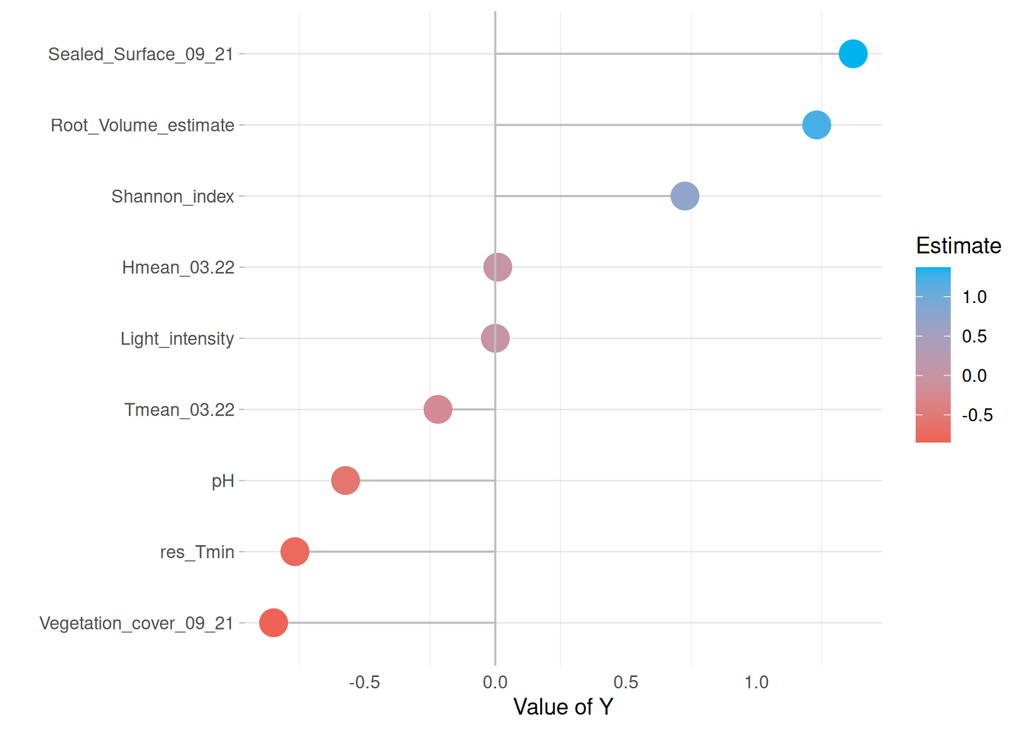

```r
glm_result %>% filter(Pr...z..<0.05) %>%
  ggplot(aes(x = reorder(Variable, Estimate), y = Estimate)) +
  coord_flip() +
  geom_segment(aes(x=Variable, xend = Variable, y = 0, yend = Estimate), color = "grey") +
  geom_point(aes(color = Estimate), size=6) +
  scale_colour_gradient2(low = "red", mid = "#CD919E",high = "#00B2EE", midpoint = -0.1)+
  theme_light() +
  theme(
    panel.grid.major.x = element_blank(),
    panel.border = element_blank(),
    axis.ticks.x = element_blank(),
    strip.text = element_text(face = "bold")) +
  geom_hline(yintercept=0, color="grey", linewidth=0.5) +
  xlab("") +
  ylab("Value of Y")
```

```r
#ggsave("Pop_size_AprilS_glmestimate.svg", plot =  last_plot(),dpi = 900, bg = NULL, scale = 2 )
```

# IX. GLM: April ~ ecological factor per habitat/Time

```r
data_size_glm <- data_pop[,(names(data_pop) %in% coef_pop_size_methods$Lasso)]
data_size_glm$Light_intensity <- data_pop$Light_intensity
data_size_glm$Type <- as.factor(data_pop$Type)
data_size_glm$April_22 <- as.factor(data_pop$April_22)
data_size_glm$EndMarch_24 <- as.factor(data_pop$EndMarch_24)
data_size_glm$April_23 <- as.factor(data_pop$April_23)
data_size_glm <- pivot_longer(data_size_glm, cols = c("April_22","April_23", "EndMarch_24"),
                                names_to = "TimePoint", values_to = "PopulationSize")
data_size_glm$PopulationSize <- as.numeric(data_size_glm$PopulationSize)
data_size_glm$PopulationSize <- data_size_glm$PopulationSize -1
```

```r
results_list <- data_size_glm %>%
  group_by(Type) %>%
  group_map(~ {
    glmmTMB(PopulationSize ~ (Tmin_09.21 + Tmax_03.22 +Tmean_03.22 + Hmean_03.22 +
                                Root_Volume_estimate +pH +Shannon_index+Sealed_Surface_09_21+
                                Vegetation_cover_09_21+ res_Tmin  +Light_intensity +
                                mean_Disturbance.Severity + mean_Disturbance.Frequency) +(1|TimePoint),
            family = nbinom2,
            data = .x)})

null_model <- data_size_glm %>%
  group_by(Type) %>%
  group_map(~ {
    glmmTMB(PopulationSize ~ 1 + (1 | TimePoint),data = .x)})
```

Extract coefficients per habitat

```r
library(broom.mixed)
results_coef <- lapply(results_list, tidy)
names(results_coef) <- unique(data_size_glm$Type)
```

## Meadow

```r
grass <- results_coef[[2]]
summary(results_list[[2]])
```

```
##  Family: nbinom2  ( log )
## Formula:
## PopulationSize ~ (Tmin_09.21 + Tmax_03.22 + Tmean_03.22 + Hmean_03.22 +
##     Root_Volume_estimate + pH + Shannon_index + Sealed_Surface_09_21 +
##     Vegetation_cover_09_21 + res_Tmin + Light_intensity + mean_Disturbance.Severity +
##     mean_Disturbance.Frequency) + (1 | TimePoint)
## Data: .x
##
##       AIC       BIC    logLik -2*log(L)  df.resid
##    1100.8    1150.8    -534.4    1068.8       152
##
## Random effects:
##
## Conditional model:
##  Groups    Name        Variance Std.Dev.
##  TimePoint (Intercept) 0.008906 0.09437
## Number of obs: 168, groups:  TimePoint, 3
##
## Dispersion parameter for nbinom2 family (): 0.496
##
## Conditional model:
##                              Estimate Std. Error z value Pr(>|z|)
## (Intercept)                -1.072e+01  8.656e+00  -1.238 0.215659
## Tmin_09.21                 -1.078e-01  5.039e-01  -0.214 0.830606
## Tmax_03.22                 -2.661e+00  1.072e+00  -2.482 0.013062 *
## Tmean_03.22                 2.422e+00  1.042e+00   2.324 0.020104 *
## Hmean_03.22                 3.000e-01  9.530e-02   3.148 0.001644 **
## Root_Volume_estimate       -2.313e+00  2.348e+00  -0.985 0.324640
## pH                          3.298e-01  6.048e-01   0.545 0.585610
## Shannon_index              -7.917e-01  4.621e-01  -1.713 0.086649 .
## Sealed_Surface_09_21        6.352e+00  2.194e+00   2.895 0.003797 **
## Vegetation_cover_09_21     -1.078e+00  7.160e-01  -1.506 0.132168
## res_Tmin                    1.354e+01  5.182e+00   2.614 0.008959 **
## Light_intensity             1.200e-03  3.484e-04   3.443 0.000576 ***
## mean_Disturbance.Severity  -1.489e+00  3.510e+00  -0.424 0.671464
## mean_Disturbance.Frequency -1.950e+00  8.952e-01  -2.179 0.029362 *
## ---
## Signif. codes:  0 '***' 0.001 '**' 0.01 '*' 0.05 '.' 0.1 ' ' 1
```

```r
car::Anova(results_list[[2]], type=c("II"))
```

|  | Chisq | Df | Pr(>Chisq) |
| --- | --- | --- | --- |
| Tmin_09.21 | 0.04576346 | 1 | 0.8306063562 |
| Tmax_03.22 | 6.16074984 | 1 | 0.0130615827 |
| Tmean_03.22 | 5.40284866 | 1 | 0.0201039124 |
| Hmean_03.22 | 9.90977898 | 1 | 0.0016440286 |
| Root_Volume_estimate | 0.97016110 | 1 | 0.3246400040 |
| pH | 0.29725330 | 1 | 0.5856095019 |
| Shannon_index | 2.93554744 | 1 | 0.0866492842 |
| Sealed_Surface_09_21 | 8.37854191 | 1 | 0.0037967690 |
| Vegetation_cover_09_21 | 2.26684892 | 1 | 0.1321683904 |
| res_Tmin | 6.83096338 | 1 | 0.0089590930 |

[output cut: 3 more lines]

```r
anova(null_model[[2]], results_list[[2]])
```

|  | Df | AIC | BIC | logLik | deviance | Chisq | Chi Df | Pr(>Chisq) |
| --- | --- | --- | --- | --- | --- | --- | --- | --- |
| null_model[[2]] | 3 | 1462.311 | 1471.683 | -728.1556 | 1456.311 | NA | NA | NA |
| results_list[[2]] | 16 | 1100.814 | 1150.798 | -534.4070 | 1068.814 | 387.4971 | 13 | 9.752077e-75 |

```r
car::Anova(results_list[[2]], test.statistic="Chisq")
```

|  | Chisq | Df | Pr(>Chisq) |
| --- | --- | --- | --- |
| Tmin_09.21 | 0.04576346 | 1 | 0.8306063562 |
| Tmax_03.22 | 6.16074984 | 1 | 0.0130615827 |
| Tmean_03.22 | 5.40284866 | 1 | 0.0201039124 |
| Hmean_03.22 | 9.90977898 | 1 | 0.0016440286 |
| Root_Volume_estimate | 0.97016110 | 1 | 0.3246400040 |
| pH | 0.29725330 | 1 | 0.5856095019 |
| Shannon_index | 2.93554744 | 1 | 0.0866492842 |
| Sealed_Surface_09_21 | 8.37854191 | 1 | 0.0037967690 |
| Vegetation_cover_09_21 | 2.26684892 | 1 | 0.1321683904 |
| res_Tmin | 6.83096338 | 1 | 0.0089590930 |

[output cut: 3 more lines]

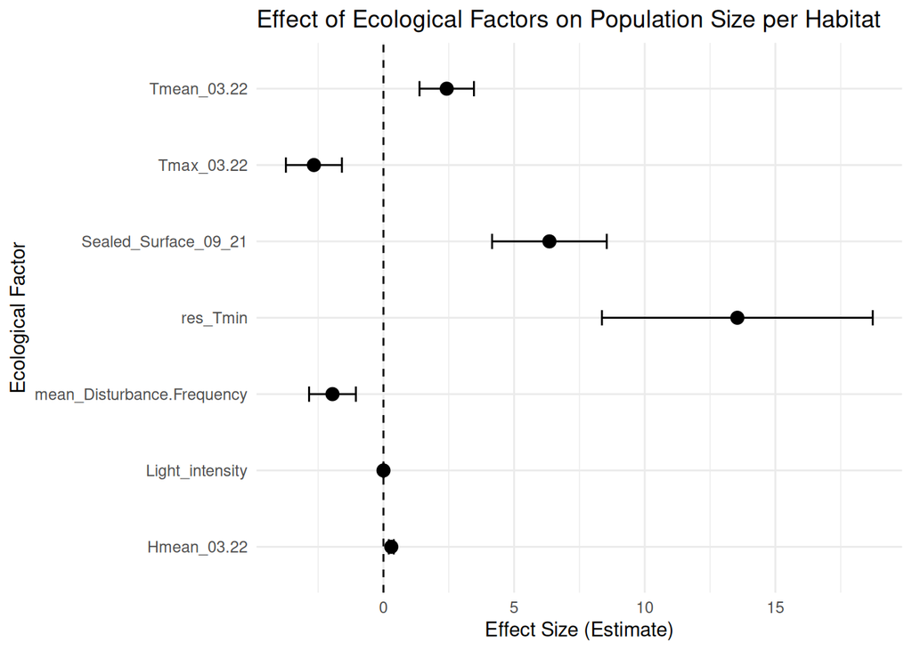

```r
grass %>% filter(p.value<0.05) %>%
  ggplot(aes(x = term, y = estimate)) +
  geom_point(position = position_dodge(width = 0.5), size = 3) +
  geom_errorbar(aes(ymin = estimate - std.error, ymax = estimate + std.error),
                width = 0.2, position = position_dodge(width = 0.5)) +
  geom_hline(yintercept = 0, linetype = "dashed") +
  labs(title = "Effect of Ecological Factors on Population Size per Habitat",
       y = "Effect Size (Estimate)",
       x = "Ecological Factor") +
  theme_minimal() +
  coord_flip()
```

## Pavement

```r
pavement <- results_coef[[3]]
summary(results_list[[3]])
```

```
##  Family: nbinom2  ( log )
## Formula:
## PopulationSize ~ (Tmin_09.21 + Tmax_03.22 + Tmean_03.22 + Hmean_03.22 +
##     Root_Volume_estimate + pH + Shannon_index + Sealed_Surface_09_21 +
##     Vegetation_cover_09_21 + res_Tmin + Light_intensity + mean_Disturbance.Severity +
##     mean_Disturbance.Frequency) + (1 | TimePoint)
## Data: .x
##
##       AIC       BIC    logLik -2*log(L)  df.resid
##    1018.5    1067.0    -493.2     986.5       137
##
## Random effects:
##
## Conditional model:
##  Groups    Name        Variance Std.Dev.
##  TimePoint (Intercept) 0.1291   0.3593
## Number of obs: 153, groups:  TimePoint, 3
##
## Dispersion parameter for nbinom2 family (): 0.484
##
## Conditional model:
##                              Estimate Std. Error z value Pr(>|z|)
## (Intercept)                 2.0992002  4.7517886   0.442   0.6587
## Tmin_09.21                  0.0747173  0.1499986   0.498   0.6184
## Tmax_03.22                 -0.4752603  0.2207423  -2.153   0.0313 *
## Tmean_03.22                -0.2741476  0.4934802  -0.555   0.5785
## Hmean_03.22                 0.0416637  0.0246497   1.690   0.0910 .
## Root_Volume_estimate        1.5668583  1.1016331   1.422   0.1549
## pH                          0.2553099  0.4816810   0.530   0.5961
## Shannon_index               0.5408073  0.4411870   1.226   0.2203
## Sealed_Surface_09_21        6.2698726  2.8970783   2.164   0.0304 *
## Vegetation_cover_09_21     -1.0168810  0.8089473  -1.257   0.2087
## res_Tmin                    2.5436681  2.9334464   0.867   0.3859
## Light_intensity             0.0011712  0.0005222   2.243   0.0249 *
## mean_Disturbance.Severity  11.9864752  7.6046165   1.576   0.1150
## mean_Disturbance.Frequency -5.1631692  3.3403593  -1.546   0.1222
## ---
## Signif. codes:  0 '***' 0.001 '**' 0.01 '*' 0.05 '.' 0.1 ' ' 1
```

```r
car::Anova(results_list[[3]], type=c("II"))
```

|  | Chisq | Df | Pr(>Chisq) |
| --- | --- | --- | --- |
| Tmin_09.21 | 0.2481235 | 1 | 0.61839945 |
| Tmax_03.22 | 4.6354502 | 1 | 0.03131793 |
| Tmean_03.22 | 0.3086238 | 1 | 0.57852593 |
| Hmean_03.22 | 2.8568799 | 1 | 0.09098382 |
| Root_Volume_estimate | 2.0229517 | 1 | 0.15493771 |
| pH | 0.2809418 | 1 | 0.59608459 |
| Shannon_index | 1.5025872 | 1 | 0.22027371 |
| Sealed_Surface_09_21 | 4.6837852 | 1 | 0.03044859 |
| Vegetation_cover_09_21 | 1.5801553 | 1 | 0.20873833 |
| res_Tmin | 0.7519078 | 1 | 0.38587288 |

[output cut: 3 more lines]

```r
anova(null_model[[3]], results_list[[3]])
```

|  | Df | AIC | BIC | logLik | deviance | Chisq | Chi Df | Pr(>Chisq) |
| --- | --- | --- | --- | --- | --- | --- | --- | --- |
| null_model[[3]] | 3 | 1380.007 | 1389.099 | -687.0037 | 1374.0074 | NA | NA | NA |
| results_list[[3]] | 16 | 1018.464 | 1066.951 | -493.2321 | 986.4643 | 387.5431 | 13 | 9.536704e-75 |

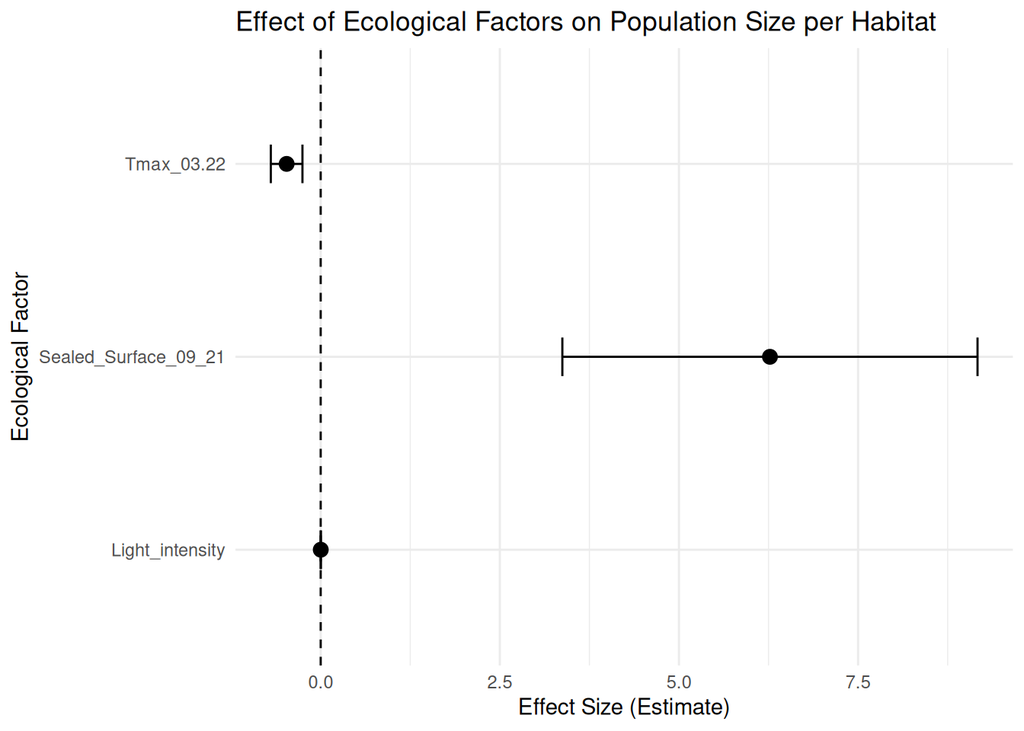

```r
pavement %>% filter(p.value<0.05) %>%
  ggplot(aes(x = term, y = estimate)) +
  geom_point(position = position_dodge(width = 0.5), size = 3) +
  geom_errorbar(aes(ymin = estimate - std.error, ymax = estimate + std.error),
                width = 0.2, position = position_dodge(width = 0.5)) +
  geom_hline(yintercept = 0, linetype = "dashed") +
  labs(title = "Effect of Ecological Factors on Population Size per Habitat",
       y = "Effect Size (Estimate)",
       x = "Ecological Factor") +
  theme_minimal() +
  coord_flip()
```

## Tree bed

```r
treebed <- results_coef[[4]]
summary(results_list[[4]])
```

```
##  Family: nbinom2  ( log )
## Formula:
## PopulationSize ~ (Tmin_09.21 + Tmax_03.22 + Tmean_03.22 + Hmean_03.22 +
##     Root_Volume_estimate + pH + Shannon_index + Sealed_Surface_09_21 +
##     Vegetation_cover_09_21 + res_Tmin + Light_intensity + mean_Disturbance.Severity +
##     mean_Disturbance.Frequency) + (1 | TimePoint)
## Data: .x
##
##       AIC       BIC    logLik -2*log(L)  df.resid
##     615.7     660.3    -291.8     583.7       104
##
## Random effects:
##
## Conditional model:
##  Groups    Name        Variance Std.Dev.
##  TimePoint (Intercept) 0.0126   0.1123
## Number of obs: 120, groups:  TimePoint, 3
##
## Dispersion parameter for nbinom2 family (): 0.569
##
## Conditional model:
##                              Estimate Std. Error z value Pr(>|z|)
## (Intercept)                -3.387e+01  2.633e+01  -1.286  0.19833
## Tmin_09.21                  1.812e+00  2.459e+00   0.737  0.46115
## Tmax_03.22                  3.051e+00  1.720e+00   1.773  0.07616 .
## Tmean_03.22                 1.962e-01  1.121e+00   0.175  0.86112
## Hmean_03.22                -4.002e-01  5.142e-01  -0.778  0.43634
## Root_Volume_estimate        5.408e+00  2.939e+00   1.840  0.06579 .
## pH                          4.719e-01  2.023e+00   0.233  0.81557
## Shannon_index               5.832e-01  5.804e-01   1.005  0.31496
## Sealed_Surface_09_21       -8.540e+00  4.451e+00  -1.919  0.05502 .
## Vegetation_cover_09_21     -8.220e-01  1.070e+00  -0.768  0.44220
## res_Tmin                   -7.556e+00  8.369e+00  -0.903  0.36657
## Light_intensity            -1.413e-03  5.322e-04  -2.655  0.00794 **
## mean_Disturbance.Severity  -5.516e+00  4.479e+00  -1.231  0.21817
## mean_Disturbance.Frequency  1.540e+00  1.223e+00   1.260  0.20783
## ---
## Signif. codes:  0 '***' 0.001 '**' 0.01 '*' 0.05 '.' 0.1 ' ' 1
```

```r
car::Anova(results_list[[4]], type=c("II"))
```

|  | Chisq | Df | Pr(>Chisq) |
| --- | --- | --- | --- |
| Tmin_09.21 | 0.54309547 | 1 | 0.461152687 |
| Tmax_03.22 | 3.14497585 | 1 | 0.076161128 |
| Tmean_03.22 | 0.03060483 | 1 | 0.861124927 |
| Hmean_03.22 | 0.60588844 | 1 | 0.436340097 |
| Root_Volume_estimate | 3.38499900 | 1 | 0.065792219 |
| pH | 0.05440100 | 1 | 0.815574880 |
| Shannon_index | 1.00976083 | 1 | 0.314960142 |
| Sealed_Surface_09_21 | 3.68156706 | 1 | 0.055017119 |
| Vegetation_cover_09_21 | 0.59056176 | 1 | 0.442201973 |
| res_Tmin | 0.81525744 | 1 | 0.366570439 |

[output cut: 3 more lines]

```r
anova(null_model[[4]], results_list[[4]])
```

|  | Df | AIC | BIC | logLik | deviance | Chisq | Chi Df | Pr(>Chisq) |
| --- | --- | --- | --- | --- | --- | --- | --- | --- |
| null_model[[4]] | 3 | 847.3485 | 855.7109 | -420.6742 | 841.3485 | NA | NA | NA |
| results_list[[4]] | 16 | 615.6739 | 660.2738 | -291.8370 | 583.6739 | 257.6745 | 13 | 1.627363e-47 |

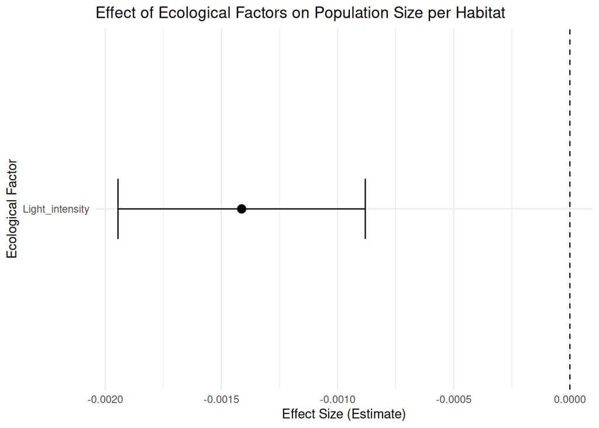

```r
treebed %>% filter(p.value<0.05) %>%
  ggplot(aes(x = term, y = estimate)) +
  geom_point(position = position_dodge(width = 0.5), size = 3) +
  geom_errorbar(aes(ymin = estimate - std.error, ymax = estimate + std.error),
                width = 0.2, position = position_dodge(width = 0.5)) +
  geom_hline(yintercept = 0, linetype = "dashed") +
  labs(title = "Effect of Ecological Factors on Population Size per Habitat",
       y = "Effect Size (Estimate)",
       x = "Ecological Factor") +
  theme_minimal() +
  coord_flip()
```

```r
results_coef <- lapply(results_list, tidy)
names(results_coef) <- unique(data_size_glm$Type)
coef_heat <- bind_rows(results_coef, .id = "Type") %>%
  filter(effect == "fixed") %>%  dplyr::select(Type, term, estimate, p.value) %>%
  filter(term != "(Intercept)") %>%
  mutate(abs_estimate = abs(estimate))  # optional for transparency or size encoding
```

## Wall

```r
ellenberg_data <- read_csv("/home/justine/sciebo/2_Ecological_parameters/2_assays/Ecological_parameters_imputed.csv")
ellenberg_data$Site_ID <- as.factor(ellenberg_data$Site_ID)
ellenberg_data$Type <- as.factor(ellenberg_data$Type)
ellenberg_data$Destroyed <- as.factor(ellenberg_data$Destroyed)
ellenberg_data$Outliers_soil <- as.factor(ellenberg_data$Outliers_soil)
ellenberg_data$Sowing_1st <- as.factor(ellenberg_data$Sowing_1st)
ellenberg_data$Sowing_2nd <- as.factor(ellenberg_data$Sowing_2nd)
ellenberg_data$Germ_2ndyear <- as.factor(ellenberg_data$Germ_2ndyear)
ellenberg_data <- ellenberg_data %>% dplyr::filter(Destroyed!="02/2022" & Destroyed !="05/2022") #Removing the destroyed site before 03/2022
ellenberg_data <- ellenberg_data %>% dplyr::filter(Sowing_1st == "09/2021" & Sowing_2nd == "no" ) #Keep the first sowing
ellenberg_data <- merge(data_pop, ellenberg_data[,c(1,120:125)], by= "Site_ID")
ellenberg_data <- ellenberg_data[,-c(1,6:14,16:23,30:34)]
```

```r
ellenberg_data$Type <- as.factor(ellenberg_data$Type)
ellenberg_data$April_22 <- as.factor(ellenberg_data$April_22)
ellenberg_data$EndMarch_24 <- as.factor(ellenberg_data$EndMarch_24)
ellenberg_data$April_23 <- as.factor(ellenberg_data$April_23)
ellenberg_data <- pivot_longer(ellenberg_data, cols = c("April_22","April_23", "EndMarch_24"),
                               names_to = "TimePoint", values_to = "PopulationSize")
ellenberg_data$PopulationSize <- as.numeric(ellenberg_data$PopulationSize)
ellenberg_data$PopulationSize <- ellenberg_data$PopulationSize -1
```

```r
results_wall <- glmmTMB(PopulationSize ~ (Sealed_Surface_09_21 + Vegetation_cover_09_21 +
                                            mean_Light +mean_Temperature +mean_Moisture+mean_Reaction+
                                            mean_Nutrients+ mean_Salinity  +
                                            mean_Disturbance.Severity + mean_Disturbance.Frequency) +(1|TimePoint),
                        family = nbinom2,
                        data =  ellenberg_data %>%filter(Type=="wall"))

null_model <- glmmTMB(PopulationSize ~ 1 + (1 | TimePoint),data = ellenberg_data %>%filter(Type=="wall"))
summary(results_wall)
```

```
##  Family: nbinom2  ( log )
## Formula:
## PopulationSize ~ (Sealed_Surface_09_21 + Vegetation_cover_09_21 +
##     mean_Light + mean_Temperature + mean_Moisture + mean_Reaction +
##     mean_Nutrients + mean_Salinity + mean_Disturbance.Severity +
##     mean_Disturbance.Frequency) + (1 | TimePoint)
## Data: ellenberg_data %>% filter(Type == "wall")
##
##       AIC       BIC    logLik -2*log(L)  df.resid
##     612.6     648.9    -293.3     586.6       107
##
## Random effects:
##
## Conditional model:
##  Groups    Name        Variance  Std.Dev.
##  TimePoint (Intercept) 1.292e-09 3.594e-05
## Number of obs: 120, groups:  TimePoint, 3
##
## Dispersion parameter for nbinom2 family (): 0.541
##
## Conditional model:
##                            Estimate Std. Error z value Pr(>|z|)
## (Intercept)                  3.7187     0.7888   4.714 2.43e-06 ***
## Sealed_Surface_09_21        -1.7069     0.9820  -1.738   0.0822 .
## Vegetation_cover_09_21      -0.8396     0.5204  -1.613   0.1066
## mean_Light                   0.3851     0.7977   0.483   0.6292
## mean_Temperature            -0.6739     0.5388  -1.251   0.2110
## mean_Moisture                0.6879     0.4335   1.587   0.1126
## mean_Reaction               -7.5052     2.5293  -2.967   0.0030 **
## mean_Nutrients               0.4653     0.4068   1.144   0.2527
## mean_Salinity               -1.9605     2.8803  -0.681   0.4961
## mean_Disturbance.Severity   50.4939    22.9860   2.197   0.0280 *
## mean_Disturbance.Frequency   5.5167     2.4275   2.273   0.0231 *
## ---
## Signif. codes:  0 '***' 0.001 '**' 0.01 '*' 0.05 '.' 0.1 ' ' 1
```

```r
car::Anova(results_wall, type=c("II"))
```

|  | Chisq | Df | Pr(>Chisq) |
| --- | --- | --- | --- |
| Sealed_Surface_09_21 | 3.0211223 | 1 | 0.082186573 |
| Vegetation_cover_09_21 | 2.6032879 | 1 | 0.106642271 |
| mean_Light | 0.2330796 | 1 | 0.629249717 |
| mean_Temperature | 1.5646597 | 1 | 0.210984249 |
| mean_Moisture | 2.5174353 | 1 | 0.112593577 |
| mean_Reaction | 8.8048448 | 1 | 0.003004317 |
| mean_Nutrients | 1.3082151 | 1 | 0.252718081 |
| mean_Salinity | 0.4632629 | 1 | 0.496102972 |
| mean_Disturbance.Severity | 4.8255807 | 1 | 0.028040418 |
| mean_Disturbance.Frequency | 5.1644441 | 1 | 0.023053834 |

```r
car::Anova(results_wall, test.statistic="Chisq")
```

|  | Chisq | Df | Pr(>Chisq) |
| --- | --- | --- | --- |
| Sealed_Surface_09_21 | 3.0211223 | 1 | 0.082186573 |
| Vegetation_cover_09_21 | 2.6032879 | 1 | 0.106642271 |
| mean_Light | 0.2330796 | 1 | 0.629249717 |
| mean_Temperature | 1.5646597 | 1 | 0.210984249 |
| mean_Moisture | 2.5174353 | 1 | 0.112593577 |
| mean_Reaction | 8.8048448 | 1 | 0.003004317 |
| mean_Nutrients | 1.3082151 | 1 | 0.252718081 |
| mean_Salinity | 0.4632629 | 1 | 0.496102972 |
| mean_Disturbance.Severity | 4.8255807 | 1 | 0.028040418 |
| mean_Disturbance.Frequency | 5.1644441 | 1 | 0.023053834 |

```r
anova(null_model, results_wall)
```

|  | Df | AIC | BIC | logLik | deviance | Chisq | Chi Df | Pr(>Chisq) |
| --- | --- | --- | --- | --- | --- | --- | --- | --- |
| null_model | 3 | 847.3485 | 855.7109 | -420.6742 | 841.3485 | NA | NA | NA |
| results_wall | 13 | 612.6463 | 648.8837 | -293.3231 | 586.6463 | 254.7022 | 10 | 5.567696e-49 |

```r
tpm <- as.data.frame(summary(results_wall)$coefficients$cond)
tpm$Variable <- rownames(tpm)
wall <- data.frame("Type"=rep("wall",11), "term"= tpm$Variable,"estimate" = tpm$Estimate, "p.value"= tpm$`Pr(>|z|)`  )
wall <- wall %>% filter(term != "(Intercept)")  %>% filter(p.value <= 0.05)
wall$abs_estimate <- abs(wall$estimate)
```

## Figure summary

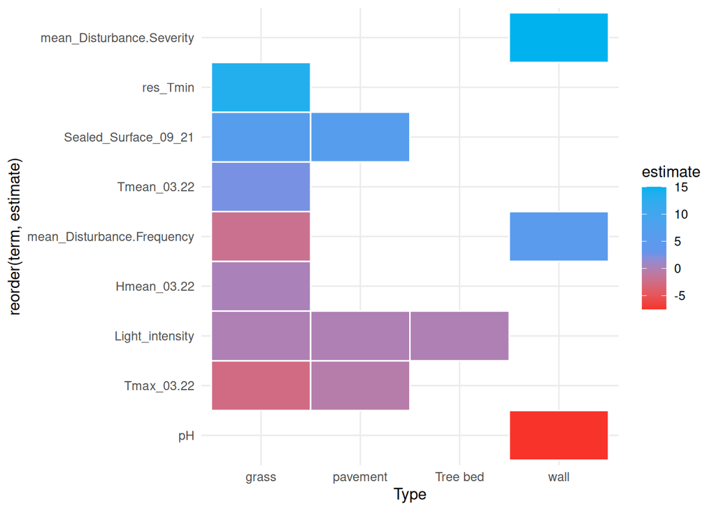

```r
coef_heat <- coef_heat %>% filter(Type != "wall")
coef_heat <- rbind(coef_heat, wall)

coef_heat$term[coef_heat$term == "mean_Temperature"] <- "Tmean_03.22"
coef_heat$term[coef_heat$term == "mean_Moisture"] <- "Hmean_03.22"
coef_heat$term[coef_heat$term == "mean_Reaction"] <- "pH"
coef_heat$estimate[coef_heat$term == "mean_Disturbance.Severity" & coef_heat$Type =="wall"] <- 15
coef_heat <- coef_heat %>% filter(p.value <0.05)


ggplot(coef_heat,aes(Type,reorder(term, estimate),fill=estimate))+
  geom_tile(color= "white",linewidth=0.5,linejoin = "mitre") +
  scale_fill_gradient2(low = "red", mid = "#6495ED",high = "#00B2EE", midpoint = 3)+
  theme_minimal()
```

```r
#ggsave("Populationsize_Aprils_glm.svg", plot =  last_plot(),dpi = 900, bg = NULL, scale = 2 )
#write.csv(coef_heat,"Coef_Populationsize_Aprils_glm.csv")
```

# X. GLM: ALL DATA ~ ecological factor per habitat/Time

I kept the parameters in common between the RDA analysis and the LASSO Adding the October, November population size

```r
data_pop <- Env_parameters %>% dplyr::filter(Destroyed == "Exist" | Destroyed =="05/2022" | Destroyed =="09/2022" | Destroyed =="04/2023") #Removing the destroyed site before 03/2022
data_pop <- data_pop %>% dplyr::filter(Sowing_1st == "09/2021")  %>% dplyr::filter(Sowing_2nd == "no")
data_pop <- data_pop[,c(1,4,15:19,25,26:55)]
data_pop$Light_intensity <- -1* data_pop$Shading
data_pop <- data_pop[,-9]
data_pop$April_22 <- as.numeric(data_pop$April_22)
data_pop$April_23 <- as.numeric(data_pop$April_23)
data_pop$EndMarch_24 <- as.numeric(data_pop$EndMarch_24)
data_pop <- data_pop %>% mutate(April_23 = replace_na(April_23, 0))
data_pop <- data_pop %>% mutate(EndMarch_24 = replace_na(EndMarch_24, 0))
data_pop <- data_pop %>%
  filter(April_22 != 0 | April_23 != 0 | EndMarch_24 != 0 )
```

```r
data_size_glm <- data_pop[,(names(data_pop) %in% coef_pop_size_methods$Lasso)]
data_size_glm$Type <- as.factor(data_pop$Type)
data_size_glm$Light_intensity <- data_pop$Light_intensity
data_size_glm$April_22 <- as.numeric(data_pop$April_22)
data_size_glm$EndMarch_24 <- as.numeric(data_pop$EndMarch_24)
data_size_glm$April_23 <- as.numeric(data_pop$April_23)
data_size_glm$Feb_22 <- as.numeric(data_pop$Feb_22)
data_size_glm$October_22 <- as.numeric(data_pop$October_22)
data_size_glm$November_22 <- as.numeric(data_pop$November_22)
data_size_glm <- pivot_longer(data_size_glm, cols = c("Feb_22", "April_22","October_22","November_22", "April_23", "EndMarch_24"),
                              names_to = "TimePoint", values_to = "PopulationSize")
data_size_glm$PopulationSize <- as.numeric(data_size_glm$PopulationSize)
```

```r
results_list <- data_size_glm %>%
  group_by(Type) %>%
  group_map(~ {
    glmmTMB(PopulationSize ~ (Tmin_09.21 + Tmax_03.22 +Tmean_03.22 + Hmean_03.22 +
                                Root_Volume_estimate +pH +Shannon_index+Sealed_Surface_09_21+
                                Vegetation_cover_09_21+ res_Tmin  +Light_intensity+
                                mean_Disturbance.Severity + mean_Disturbance.Frequency) +(1|TimePoint),
            family = nbinom2,
            data = .x)})

null_model <- data_size_glm %>%
  group_by(Type) %>%
  group_map(~ {
    glmmTMB(PopulationSize ~ 1 + (1 | TimePoint),data = .x)})
```

Extract coefficients per habitat

```r
library(broom.mixed)
results_coef <- lapply(results_list, tidy)
names(results_coef) <- unique(data_size_glm$Type)
```

## Meadow

```r
grass <- results_coef[[2]]
summary(results_list[[2]])
```

```
##  Family: nbinom2  ( log )
## Formula:
## PopulationSize ~ (Tmin_09.21 + Tmax_03.22 + Tmean_03.22 + Hmean_03.22 +
##     Root_Volume_estimate + pH + Shannon_index + Sealed_Surface_09_21 +
##     Vegetation_cover_09_21 + res_Tmin + Light_intensity + mean_Disturbance.Severity +
##     mean_Disturbance.Frequency) + (1 | TimePoint)
## Data: .x
##
##       AIC       BIC    logLik -2*log(L)  df.resid
##      2092      2153     -1030      2060       320
##
## Random effects:
##
## Conditional model:
##  Groups    Name        Variance Std.Dev.
##  TimePoint (Intercept) 0.1747   0.418
## Number of obs: 336, groups:  TimePoint, 6
##
## Dispersion parameter for nbinom2 family (): 0.456
##
## Conditional model:
##                              Estimate Std. Error z value Pr(>|z|)
## (Intercept)                -1.157e+01  6.541e+00  -1.768  0.07699 .
## Tmin_09.21                  2.269e-01  3.585e-01   0.633  0.52678
## Tmax_03.22                 -3.306e+00  7.382e-01  -4.479 7.51e-06 ***
## Tmean_03.22                 3.458e+00  7.327e-01   4.720 2.36e-06 ***
## Hmean_03.22                 2.646e-01  6.407e-02   4.130 3.62e-05 ***
## Root_Volume_estimate       -3.530e+00  1.793e+00  -1.969  0.04899 *
## pH                          1.388e-01  4.396e-01   0.316  0.75222
## Shannon_index              -9.404e-01  3.227e-01  -2.914  0.00356 **
## Sealed_Surface_09_21        6.152e+00  1.566e+00   3.928 8.55e-05 ***
## Vegetation_cover_09_21     -1.228e+00  5.357e-01  -2.292  0.02189 *
## res_Tmin                    1.506e+01  3.463e+00   4.349 1.37e-05 ***
## Light_intensity             1.383e-03  2.665e-04   5.192 2.08e-07 ***
## mean_Disturbance.Severity   5.633e-01  2.406e+00   0.234  0.81486
## mean_Disturbance.Frequency -2.128e+00  7.230e-01  -2.943  0.00325 **
## ---
## Signif. codes:  0 '***' 0.001 '**' 0.01 '*' 0.05 '.' 0.1 ' ' 1
```

```r
car::Anova(results_list[[2]], type=c("III"))
```

|  | Chisq | Df | Pr(>Chisq) |
| --- | --- | --- | --- |
| (Intercept) | 3.12728524 | 1 | 7.699185e-02 |
| Tmin_09.21 | 0.40060014 | 1 | 5.267795e-01 |
| Tmax_03.22 | 20.05790386 | 1 | 7.513237e-06 |
| Tmean_03.22 | 22.27896184 | 1 | 2.357756e-06 |
| Hmean_03.22 | 17.06052421 | 1 | 3.620716e-05 |
| Root_Volume_estimate | 3.87585832 | 1 | 4.898526e-02 |
| pH | 0.09967793 | 1 | 7.522165e-01 |
| Shannon_index | 8.49377574 | 1 | 3.563635e-03 |
| Sealed_Surface_09_21 | 15.43288067 | 1 | 8.548783e-05 |
| Vegetation_cover_09_21 | 5.25427572 | 1 | 2.189291e-02 |

[output cut: 4 more lines]

```r
anova(null_model[[2]], results_list[[2]])
```

|  | Df | AIC | BIC | logLik | deviance | Chisq | Chi Df | Pr(>Chisq) |
| --- | --- | --- | --- | --- | --- | --- | --- | --- |
| null_model[[2]] | 3 | 3196.030 | 3207.481 | -1595.015 | 3190.030 | NA | NA | NA |
| results_list[[2]] | 16 | 2091.956 | 2153.029 | -1029.978 | 2059.956 | 1130.075 | 13 | 1.944841e-233 |

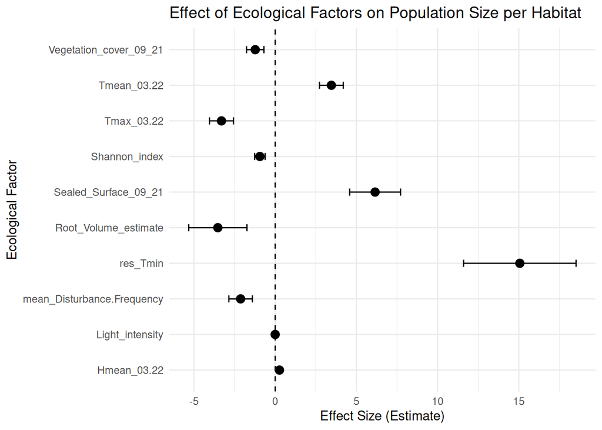

```r
grass %>% filter(p.value<0.05) %>%
  ggplot(aes(x = term, y = estimate)) +
  geom_point(position = position_dodge(width = 0.5), size = 3) +
  geom_errorbar(aes(ymin = estimate - std.error, ymax = estimate + std.error),
                width = 0.2, position = position_dodge(width = 0.5)) +
  geom_hline(yintercept = 0, linetype = "dashed") +
  labs(title = "Effect of Ecological Factors on Population Size per Habitat",
       y = "Effect Size (Estimate)",
       x = "Ecological Factor") +
  theme_minimal() +
  coord_flip()
```

## Pavement

```r
pavement <- results_coef[[3]]
summary(results_list[[3]])
```

```
##  Family: nbinom2  ( log )
## Formula:
## PopulationSize ~ (Tmin_09.21 + Tmax_03.22 + Tmean_03.22 + Hmean_03.22 +
##     Root_Volume_estimate + pH + Shannon_index + Sealed_Surface_09_21 +
##     Vegetation_cover_09_21 + res_Tmin + Light_intensity + mean_Disturbance.Severity +
##     mean_Disturbance.Frequency) + (1 | TimePoint)
## Data: .x
##
##       AIC       BIC    logLik -2*log(L)  df.resid
##    1784.9    1844.1    -876.5    1752.9       282
##
## Random effects:
##
## Conditional model:
##  Groups    Name        Variance Std.Dev.
##  TimePoint (Intercept) 0.7621   0.873
## Number of obs: 298, groups:  TimePoint, 6
##
## Dispersion parameter for nbinom2 family (): 0.35
##
## Conditional model:
##                              Estimate Std. Error z value Pr(>|z|)
## (Intercept)                 0.1786449  4.1286441   0.043 0.965487
## Tmin_09.21                  0.0470251  0.1342833   0.350 0.726194
## Tmax_03.22                 -0.0522134  0.2097007  -0.249 0.803368
## Tmean_03.22                -1.0383227  0.4348432  -2.388 0.016949 *
## Hmean_03.22                 0.0738476  0.0213379   3.461 0.000538 ***
## Root_Volume_estimate        2.2688653  0.9929987   2.285 0.022321 *
## pH                          0.2811160  0.4214073   0.667 0.504716
## Shannon_index               0.8982266  0.4117020   2.182 0.029129 *
## Sealed_Surface_09_21        6.3365105  2.5598766   2.475 0.013312 *
## Vegetation_cover_09_21     -1.9357681  0.8151870  -2.375 0.017567 *
## res_Tmin                   -0.6017991  2.6306730  -0.229 0.819054
## Light_intensity             0.0016961  0.0004311   3.934 8.35e-05 ***
## mean_Disturbance.Severity  18.5482062  7.3407279   2.527 0.011512 *
## mean_Disturbance.Frequency -6.6210718  3.0966281  -2.138 0.032504 *
## ---
## Signif. codes:  0 '***' 0.001 '**' 0.01 '*' 0.05 '.' 0.1 ' ' 1
```

```r
car::Anova(results_list[[3]], type=c("III"))
```

|  | Chisq | Df | Pr(>Chisq) |
| --- | --- | --- | --- |
| (Intercept) | 0.00187226 | 1 | 0.9654866043 |
| Tmin_09.21 | 0.12263536 | 1 | 0.7261936204 |
| Tmax_03.22 | 0.06199606 | 1 | 0.8033684497 |
| Tmean_03.22 | 5.70163346 | 1 | 0.0169491320 |
| Hmean_03.22 | 11.97754692 | 1 | 0.0005384542 |
| Root_Volume_estimate | 5.22059567 | 1 | 0.0223209040 |
| pH | 0.44500723 | 1 | 0.5047155252 |
| Shannon_index | 4.75998693 | 1 | 0.0291287693 |
| Sealed_Surface_09_21 | 6.12720270 | 1 | 0.0133117326 |
| Vegetation_cover_09_21 | 5.63887121 | 1 | 0.0175665134 |

[output cut: 4 more lines]

```r
anova(null_model[[3]], results_list[[3]])
```

|  | Df | AIC | BIC | logLik | deviance | Chisq | Chi Df | Pr(>Chisq) |
| --- | --- | --- | --- | --- | --- | --- | --- | --- |
| null_model[[3]] | 3 | 3177.653 | 3188.744 | -1585.8265 | 3171.653 | NA | NA | NA |
| results_list[[3]] | 16 | 1784.916 | 1844.069 | -876.4579 | 1752.916 | 1418.737 | 13 | 1.409649e-295 |

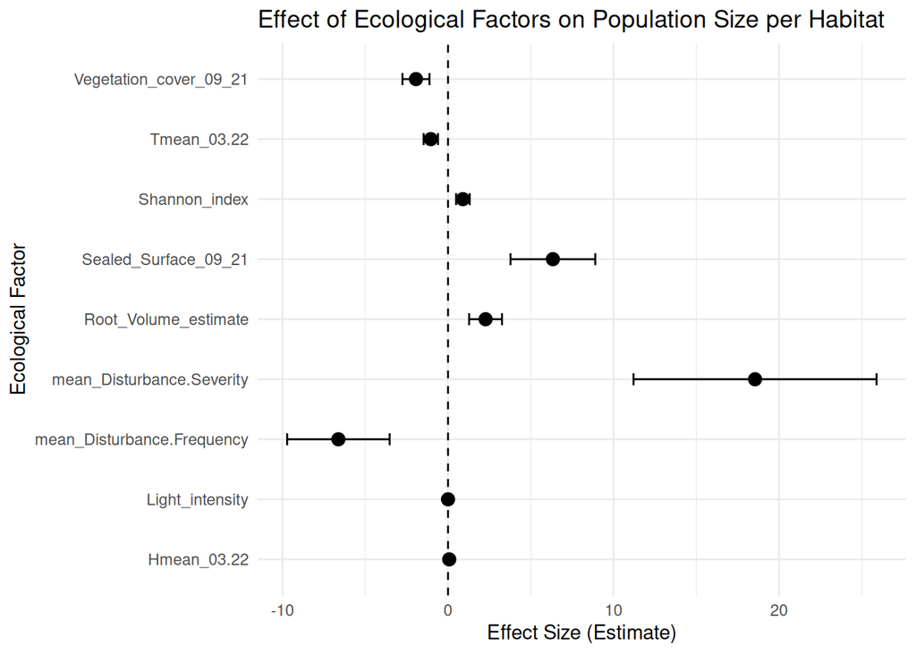

```r
pavement %>% filter(p.value<0.05) %>%
  ggplot(aes(x = term, y = estimate)) +
  geom_point(position = position_dodge(width = 0.5), size = 3) +
  geom_errorbar(aes(ymin = estimate - std.error, ymax = estimate + std.error),
                width = 0.2, position = position_dodge(width = 0.5)) +
  geom_hline(yintercept = 0, linetype = "dashed") +
  labs(title = "Effect of Ecological Factors on Population Size per Habitat",
       y = "Effect Size (Estimate)",
       x = "Ecological Factor") +
  theme_minimal() +
  coord_flip()
```

## Tree bed

```r
treebed <- results_coef[[4]]
summary(results_list[[4]])
```

```
##  Family: nbinom2  ( log )
## Formula:
## PopulationSize ~ (Tmin_09.21 + Tmax_03.22 + Tmean_03.22 + Hmean_03.22 +
##     Root_Volume_estimate + pH + Shannon_index + Sealed_Surface_09_21 +
##     Vegetation_cover_09_21 + res_Tmin + Light_intensity + mean_Disturbance.Severity +
##     mean_Disturbance.Frequency) + (1 | TimePoint)
## Data: .x
##
##       AIC       BIC    logLik -2*log(L)  df.resid
##    1340.9    1396.6    -654.4    1308.9       224
##
## Random effects:
##
## Conditional model:
##  Groups    Name        Variance Std.Dev.
##  TimePoint (Intercept) 0.1015   0.3186
## Number of obs: 240, groups:  TimePoint, 6
##
## Dispersion parameter for nbinom2 family (): 0.544
##
## Conditional model:
##                              Estimate Std. Error z value Pr(>|z|)
## (Intercept)                -4.798e+01  1.969e+01  -2.437  0.01481 *
## Tmin_09.21                  2.691e+00  1.819e+00   1.479  0.13906
## Tmax_03.22                  2.922e+00  1.177e+00   2.483  0.01302 *
## Tmean_03.22                 8.082e-01  8.570e-01   0.943  0.34564
## Hmean_03.22                -4.621e-01  3.754e-01  -1.231  0.21838
## Root_Volume_estimate        5.630e+00  2.169e+00   2.595  0.00945 **
## pH                          7.600e-01  1.579e+00   0.481  0.63031
## Shannon_index               6.413e-01  4.219e-01   1.520  0.12847
## Sealed_Surface_09_21       -7.535e+00  3.090e+00  -2.438  0.01476 *
## Vegetation_cover_09_21     -6.051e-01  8.139e-01  -0.743  0.45721
## res_Tmin                   -3.572e+00  5.864e+00  -0.609  0.54250
## Light_intensity            -1.584e-03  3.597e-04  -4.404 1.06e-05 ***
## mean_Disturbance.Severity  -7.098e+00  3.397e+00  -2.089  0.03669 *
## mean_Disturbance.Frequency  1.379e+00  8.874e-01   1.554  0.12010
## ---
## Signif. codes:  0 '***' 0.001 '**' 0.01 '*' 0.05 '.' 0.1 ' ' 1
```

```r
car::Anova(results_list[[4]], type=c("III"))
```

|  | Chisq | Df | Pr(>Chisq) |
| --- | --- | --- | --- |
| (Intercept) | 5.9387369 | 1 | 1.481163e-02 |
| Tmin_09.21 | 2.1882846 | 1 | 1.390641e-01 |
| Tmax_03.22 | 6.1662658 | 1 | 1.302092e-02 |
| Tmean_03.22 | 0.8893878 | 1 | 3.456433e-01 |
| Hmean_03.22 | 1.5150067 | 1 | 2.183767e-01 |
| Root_Volume_estimate | 6.7357294 | 1 | 9.450058e-03 |
| pH | 0.2316404 | 1 | 6.303102e-01 |
| Shannon_index | 2.3109523 | 1 | 1.284653e-01 |
| Sealed_Surface_09_21 | 5.9454436 | 1 | 1.475538e-02 |
| Vegetation_cover_09_21 | 0.5527142 | 1 | 4.572108e-01 |

[output cut: 4 more lines]

```r
anova(null_model[[4]], results_list[[4]])
```

|  | Df | AIC | BIC | logLik | deviance | Chisq | Chi Df | Pr(>Chisq) |
| --- | --- | --- | --- | --- | --- | --- | --- | --- |
| null_model[[4]] | 3 | 1960.970 | 1971.412 | -977.4852 | 1954.970 | NA | NA | NA |
| results_list[[4]] | 16 | 1340.881 | 1396.571 | -654.4403 | 1308.881 | 646.0898 | 13 | 1.128632e-129 |

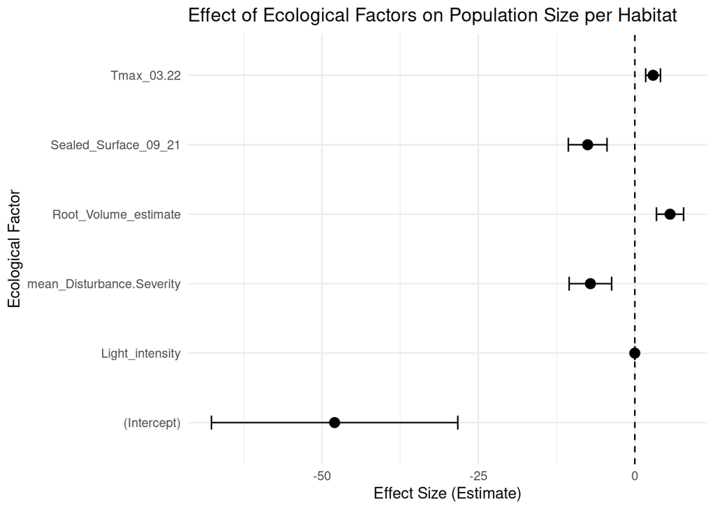

```r
treebed %>% filter(p.value<0.05) %>%
  ggplot(aes(x = term, y = estimate)) +
  geom_point(position = position_dodge(width = 0.5), size = 3) +
  geom_errorbar(aes(ymin = estimate - std.error, ymax = estimate + std.error),
                width = 0.2, position = position_dodge(width = 0.5)) +
  geom_hline(yintercept = 0, linetype = "dashed") +
  labs(title = "Effect of Ecological Factors on Population Size per Habitat",
       y = "Effect Size (Estimate)",
       x = "Ecological Factor") +
  theme_minimal() +
  coord_flip()
```

```r
results_coef <- lapply(results_list, tidy)
names(results_coef) <- unique(data_size_glm$Type)
coef_heat <- bind_rows(results_coef, .id = "Type") %>%
  filter(effect == "fixed") %>%  dplyr::select(Type, term, estimate, p.value) %>%
  filter(term != "(Intercept)") %>%
  mutate(abs_estimate = abs(estimate))  # optional for transparency or size encoding
```

## Wall

```r
ellenberg_data <- read_csv("/home/justine/sciebo/2_Ecological_parameters/2_assays/Ecological_parameters_imputed.csv")
ellenberg_data$Site_ID <- as.factor(ellenberg_data$Site_ID)
ellenberg_data$Type <- as.factor(ellenberg_data$Type)
ellenberg_data$Destroyed <- as.factor(ellenberg_data$Destroyed)
ellenberg_data$Outliers_soil <- as.factor(ellenberg_data$Outliers_soil)
ellenberg_data$Sowing_1st <- as.factor(ellenberg_data$Sowing_1st)
ellenberg_data$Sowing_2nd <- as.factor(ellenberg_data$Sowing_2nd)
ellenberg_data$Germ_2ndyear <- as.factor(ellenberg_data$Germ_2ndyear)
ellenberg_data <- ellenberg_data %>% dplyr::filter(Destroyed!="02/2022" & Destroyed !="05/2022") #Removing the destroyed site before 03/2022
ellenberg_data <- ellenberg_data %>% dplyr::filter(Sowing_1st == "09/2021" & Sowing_2nd == "no" ) #Keep the first sowing
ellenberg_data <- merge(data_pop, ellenberg_data[,c(1,120:125)], by= "Site_ID")
ellenberg_data <- ellenberg_data[,-c(1,9:17,19:26,33:37)]
```

```r
ellenberg_data$Type <- as.factor(ellenberg_data$Type)
ellenberg_data$April_22 <- as.numeric(ellenberg_data$April_22)
ellenberg_data$EndMarch_24 <- as.numeric(ellenberg_data$EndMarch_24)
ellenberg_data$April_23 <- as.numeric(ellenberg_data$April_23)
ellenberg_data$Feb_22 <- as.numeric(ellenberg_data$Feb_22)
ellenberg_data$October_22 <- as.numeric(ellenberg_data$October_22)
ellenberg_data$November_22 <- as.numeric(ellenberg_data$November_22)
ellenberg_data <- pivot_longer(ellenberg_data, cols = c("Feb_22", "April_22","October_22","November_22", "April_23", "EndMarch_24"),
                              names_to = "TimePoint", values_to = "PopulationSize")
ellenberg_data$PopulationSize <- as.numeric(ellenberg_data$PopulationSize)
```

```r
results_wall <- glmmTMB(PopulationSize ~ (Sealed_Surface_09_21 + Vegetation_cover_09_21 +Root_Volume_estimate+Shannon_index+
                                            mean_Light +mean_Temperature +mean_Moisture+mean_Reaction+
                                            mean_Nutrients+ mean_Salinity  +Light_intensity +
                                            mean_Disturbance.Severity + mean_Disturbance.Frequency) +(1|TimePoint),
                        family = nbinom2,
                        data =  ellenberg_data %>%filter(Type=="wall"))

null_model <- glmmTMB(PopulationSize ~ 1 + (1 | TimePoint),data = ellenberg_data %>%filter(Type=="wall"))
summary(results_wall)
```

```
##  Family: nbinom2  ( log )
## Formula:
## PopulationSize ~ (Sealed_Surface_09_21 + Vegetation_cover_09_21 +
##     Root_Volume_estimate + Shannon_index + mean_Light + mean_Temperature +
##     mean_Moisture + mean_Reaction + mean_Nutrients + mean_Salinity +
##     Light_intensity + mean_Disturbance.Severity + mean_Disturbance.Frequency) +
##     (1 | TimePoint)
## Data: ellenberg_data %>% filter(Type == "wall")
##
##       AIC       BIC    logLik -2*log(L)  df.resid
##    1346.6    1402.3    -657.3    1314.6       224
##
## Random effects:
##
## Conditional model:
##  Groups    Name        Variance Std.Dev.
##  TimePoint (Intercept) 0.08626  0.2937
## Number of obs: 240, groups:  TimePoint, 6
##
## Dispersion parameter for nbinom2 family (): 0.523
##
## Conditional model:
##                              Estimate Std. Error z value Pr(>|z|)
## (Intercept)                 1.7057739  0.9244348   1.845 0.065007 .
## Sealed_Surface_09_21       -1.0254850  0.7597895  -1.350 0.177113
## Vegetation_cover_09_21      0.3252137  0.5548772   0.586 0.557808
## Root_Volume_estimate        0.2723108  1.7334643   0.157 0.875174
## Shannon_index               0.3771820  0.3642895   1.035 0.300486
## mean_Light                 -0.3062679  0.6001754  -0.510 0.609843
## mean_Temperature           -0.1406614  0.6479185  -0.217 0.828133
## mean_Moisture               0.6656383  0.4050299   1.643 0.100294
## mean_Reaction              -8.5523995  2.3734962  -3.603 0.000314 ***
## mean_Nutrients              0.4903685  0.3112739   1.575 0.115173
## mean_Salinity              -2.2649208  2.4691238  -0.917 0.358987
## Light_intensity            -0.0006776  0.0004244  -1.596 0.110385
## mean_Disturbance.Severity  65.7826678 22.5472480   2.918 0.003528 **
## mean_Disturbance.Frequency  5.4022665  1.7900558   3.018 0.002545 **
## ---
## Signif. codes:  0 '***' 0.001 '**' 0.01 '*' 0.05 '.' 0.1 ' ' 1
```

```r
car::Anova(results_wall, type=c("III"))
```

|  | Chisq | Df | Pr(>Chisq) |
| --- | --- | --- | --- |
| (Intercept) | 3.40479016 | 1 | 0.0650073817 |
| Sealed_Surface_09_21 | 1.82167967 | 1 | 0.1771134716 |
| Vegetation_cover_09_21 | 0.34351360 | 1 | 0.5578080900 |
| Root_Volume_estimate | 0.02467743 | 1 | 0.8751735114 |
| Shannon_index | 1.07203396 | 1 | 0.3004864747 |
| mean_Light | 0.26040340 | 1 | 0.6098431497 |
| mean_Temperature | 0.04713125 | 1 | 0.8281325040 |
| mean_Moisture | 2.70086224 | 1 | 0.1002939929 |
| mean_Reaction | 12.98371168 | 1 | 0.0003142125 |
| mean_Nutrients | 2.48175968 | 1 | 0.1151733315 |

[output cut: 4 more lines]

```r
anova(null_model, results_wall)
```

|  | Df | AIC | BIC | logLik | deviance | Chisq | Chi Df | Pr(>Chisq) |
| --- | --- | --- | --- | --- | --- | --- | --- | --- |
| null_model | 3 | 1960.970 | 1971.412 | -977.4852 | 1954.970 | NA | NA | NA |
| results_wall | 16 | 1346.636 | 1402.326 | -657.3178 | 1314.636 | 640.3348 | 13 | 1.909514e-128 |

```r
tpm <- as.data.frame(summary(results_wall)$coefficients$cond)
tpm$Variable <- rownames(tpm)
wall <- data.frame("Type"=rep("wall",14), "term"= tpm$Variable,"estimate" = tpm$Estimate, "p.value"= tpm$`Pr(>|z|)`  )
wall <- wall %>% filter(term != "(Intercept)")  %>% filter(p.value <= 0.05)
wall$abs_estimate <- abs(wall$estimate)
```

## Figure summary

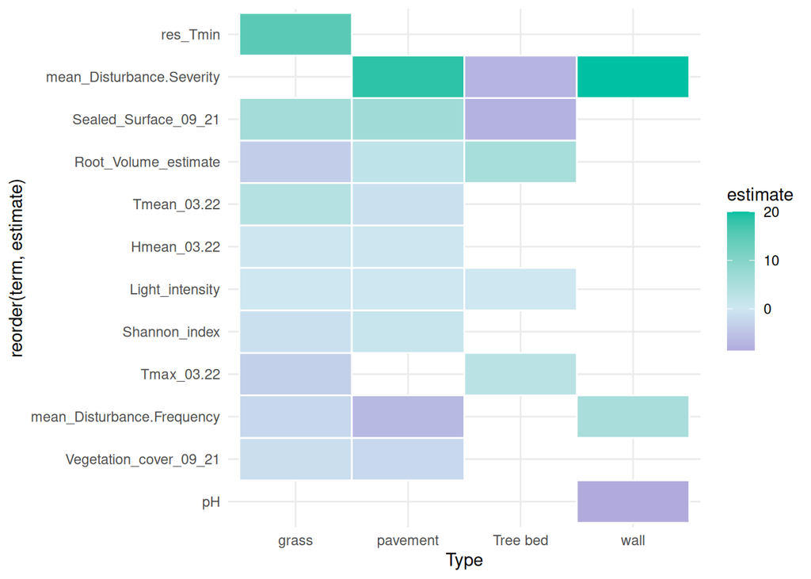

```r
coef_heat <- coef_heat %>% filter(Type != "wall")
coef_heat <- rbind(coef_heat, wall)

coef_heat$term[coef_heat$term == "mean_Temperature"] <- "Tmean_03.22"
coef_heat$term[coef_heat$term == "mean_Moisture"] <- "Hmean_03.22"
coef_heat$term[coef_heat$term == "mean_Reaction"] <- "pH"
coef_heat$estimate[coef_heat$term == "mean_Disturbance.Severity" & coef_heat$Type =="wall"] <- 20

coef_heat <- coef_heat %>% filter(p.value<0.05)


ggplot(coef_heat,aes(Type,reorder(term, estimate),fill=estimate))+
  geom_tile(color= "white",linewidth=0.5,linejoin = "mitre") +
  scale_fill_gradient2(low = "#845ec2", mid = "#cee7f1",high = "#00c0a3", midpoint = 0)+
  theme_minimal()
```

```r
#ggsave("Populationsize_alldatas_glm.svg", plot =  last_plot(),dpi = 900, bg = NULL, scale = 2 )
#write.csv(coef_heat,"Coef_Populationsize_alldata_glm.csv")
```